# Term Deposit Subscription Prediction

## Introduction

The data is related with direct marketing campaigns of a Portuguese banking institution. The marketing campaigns were based on phone calls. Often, more than one contact to the same client was required, in order to access if the product (bank term deposit) would be ('yes') or not ('no') subscribed.

##### Domain

Business

##### Goal

Using the data collected from existing customers, build a model that will help the marketing team identify potential customers who are relatively more likely to subscribe term deposit and thus increase their hit ratio

## Imports

```python
import warnings
warnings.filterwarnings('ignore')

import os,sys
import numpy as np
import pandas as pd
import matplotlib.pyplot as plt
import seaborn as sns
from IPython.core.display import display, HTML
from sklearn.linear_model import LogisticRegression
from sklearn.tree import DecisionTreeClassifier
from sklearn.ensemble import RandomForestClassifier
from sklearn.ensemble import BaggingClassifier
from sklearn.ensemble import AdaBoostClassifier
from sklearn.ensemble import GradientBoostingClassifier
from sklearn.metrics import classification_report, confusion_matrix, recall_score, precision_score, f1_score, roc_auc_score,accuracy_score
from sklearn.model_selection import train_test_split
 #!pip install yellowbrick
from yellowbrick.classifier import ClassificationReport, ROCAUC

from sklearn.tree import export_graphviz
from six import StringIO
from IPython.display import Image
import pydotplus
import graphviz


%matplotlib inline

# Increase cell width
display(HTML("<style>.container { width:98% !important; }</style>"))

# Update seaborn default style
sns.set_style(style='darkgrid')
sns.set_palette("muted")

my_random_state = 5
```

## Read Data

```python
bank_full_df = pd.read_csv("bank-full.csv")
```

```python
print("")
print("Bank Marketing Campaign Data")
print("****************************")
print("")
display(HTML(bank_full_df.head(10).to_html()))
```

```
Bank Marketing Campaign Data
```

|  | age | job | marital | education | default | balance | housing | loan | contact | day | month | duration | campaign | pdays | previous | poutcome | Target |
| --- | --- | --- | --- | --- | --- | --- | --- | --- | --- | --- | --- | --- | --- | --- | --- | --- | --- |
| 0 | 58 | management | married | tertiary | no | 2143 | yes | no | unknown | 5 | may | 261 | 1 | -1 | 0 | unknown | no |
| 1 | 44 | technician | single | secondary | no | 29 | yes | no | unknown | 5 | may | 151 | 1 | -1 | 0 | unknown | no |
| 2 | 33 | entrepreneur | married | secondary | no | 2 | yes | yes | unknown | 5 | may | 76 | 1 | -1 | 0 | unknown | no |
| 3 | 47 | blue-collar | married | unknown | no | 1506 | yes | no | unknown | 5 | may | 92 | 1 | -1 | 0 | unknown | no |
| 4 | 33 | unknown | single | unknown | no | 1 | no | no | unknown | 5 | may | 198 | 1 | -1 | 0 | unknown | no |
| 5 | 35 | management | married | tertiary | no | 231 | yes | no | unknown | 5 | may | 139 | 1 | -1 | 0 | unknown | no |
| 6 | 28 | management | single | tertiary | no | 447 | yes | yes | unknown | 5 | may | 217 | 1 | -1 | 0 | unknown | no |
| 7 | 42 | entrepreneur | divorced | tertiary | yes | 2 | yes | no | unknown | 5 | may | 380 | 1 | -1 | 0 | unknown | no |
| 8 | 58 | retired | married | primary | no | 121 | yes | no | unknown | 5 | may | 50 | 1 | -1 | 0 | unknown | no |
| 9 | 43 | technician | single | secondary | no | 593 | yes | no | unknown | 5 | may | 55 | 1 | -1 | 0 | unknown | no |

## Univariate Analysis

### Data Types and Description

#### Info

```python
print("")
print("Marketing Data -- Info")
print(bank_full_df.info())
```

```
Marketing Data -- Info
<class 'pandas.core.frame.DataFrame'>
RangeIndex: 45211 entries, 0 to 45210
Data columns (total 17 columns):
 #   Column     Non-Null Count  Dtype
---  ------     --------------  -----
 0   age        45211 non-null  int64
 1   job        45211 non-null  object
 2   marital    45211 non-null  object
 3   education  45211 non-null  object
 4   default    45211 non-null  object
 5   balance    45211 non-null  int64
 6   housing    45211 non-null  object
 7   loan       45211 non-null  object
 8   contact    45211 non-null  object
 9   day        45211 non-null  int64
 10  month      45211 non-null  object
 11  duration   45211 non-null  int64
 12  campaign   45211 non-null  int64
 13  pdays      45211 non-null  int64
 14  previous   45211 non-null  int64
 15  poutcome   45211 non-null  object
 16  Target     45211 non-null  object
dtypes: int64(7), object(10)
memory usage: 5.9+ MB
None
```

##### Observation

Data types based on the description provided in the problem statement

```
age       (numeric)     : age of the customer
job       (categorical) : type of job
marital   (categorical) : marital status
education (categorical) : education level
default   (binary)      : has credit in default
balance   (numeric)     : balance in the account
housing   (binary)      : has housing loan
loan      (binary)      : has personal loan
contact   (categorical) : contact communication type
day       (numeric)     : last contact day of the month
month     (categorical) : last contact month of year
duration  (numeric)     : last contact duration, in seconds
campaign  (numeric)     : number of contacts performed during this campaign and for this client
pdays     (numeric)     : number of days that passed by after the client was last contacted from a previous campaign (-1 tells us the person has not been contacted or contact period is beyond 900 days)
previous  (numeric)     : number of contacts performed before this campaign and for this client
poutcome  (categorical) : outcome of the previous marketing campaign
Target    (binary)      : has the client subscribed a term deposit
```

Based on this, we noticed all the attributes have the right data types.

```python
bank_mark_df = bank_full_df.copy()
```

#### Shape

```python
print("")
print("Marketing Data -- Shape")
print(bank_mark_df.shape)
```

```
Marketing Data -- Shape
(45211, 17)
```

##### Observation

- The dataset contains **45211** customers

```python
print(bank_mark_df["Target"].value_counts(normalize=True)*100)
```

```
no     88.30152
yes    11.69848
Name: Target, dtype: float64
```

##### Observation

- Of the **45211** customers, **11.69%** subscribed to a term deposit during the current campaign

#### Describe

```python
print("")
print("Marketing Data -- Describe")
display(HTML(bank_mark_df.describe().T.to_html()))
```

```
Marketing Data -- Describe
```

|  | count | mean | std | min | 25% | 50% | 75% | max |
| --- | --- | --- | --- | --- | --- | --- | --- | --- |
| age | 45211.0 | 40.936210 | 10.618762 | 18.0 | 33.0 | 39.0 | 48.0 | 95.0 |
| balance | 45211.0 | 1362.272058 | 3044.765829 | -8019.0 | 72.0 | 448.0 | 1428.0 | 102127.0 |
| day | 45211.0 | 15.806419 | 8.322476 | 1.0 | 8.0 | 16.0 | 21.0 | 31.0 |
| duration | 45211.0 | 258.163080 | 257.527812 | 0.0 | 103.0 | 180.0 | 319.0 | 4918.0 |
| campaign | 45211.0 | 2.763841 | 3.098021 | 1.0 | 1.0 | 2.0 | 3.0 | 63.0 |
| pdays | 45211.0 | 40.197828 | 100.128746 | -1.0 | -1.0 | -1.0 | -1.0 | 871.0 |
| previous | 45211.0 | 0.580323 | 2.303441 | 0.0 | 0.0 | 0.0 | 0.0 | 275.0 |

##### Observations

- **age** - Minimum age for customers is **18**. The median age for customers is **39**. The data doesnt look abnormal
- **balance** - Minimum balance seems to be **-8019**. This could be because of overdraft. This will require further analysis.
- **day** - Min is **1** and Max is **31**. This seems to represent a valid range of data for a day in a month.
- **duration** - The minimum duration is **0**. The median is **180 seconds (3 minutues)**. But the maximum is **4918 second (1.3 hrs)**. This could be an outlier where the call was not terminated properly.
- **campaign** - The minimum contact is **1** for this campaign. The median is **2** contacts. But the maximum is **63** contacts. This shows the campaign agent was persistent to reach this customer.
- **pdays** - The minimum, median and the Q3 are **-1**. This shows that for majorty of customers, they were either never contacted in the previous campaign or it has been more than 900 days (~ 2.5 years) since they have been contacted

#### Null Values

```python
print("")
print("Marketing Data -- IsNull")
print(bank_mark_df.isnull().sum())
print("")
print("Marketing Data - IsNa")
print(bank_mark_df.isna().sum())
print("")
```

```
Marketing Data -- IsNull
age          0
job          0
marital      0
education    0
default      0
balance      0
housing      0
loan         0
contact      0
day          0
month        0
duration     0
campaign     0
pdays        0
previous     0
poutcome     0
Target       0
dtype: int64

Marketing Data - IsNa
age          0
job          0
marital      0
education    0
default      0
balance      0
housing      0
loan         0
contact      0
day          0
month        0
duration     0
campaign     0
pdays        0
previous     0
poutcome     0
Target       0
dtype: int64
```

##### Observation

- There doesnt seem to be any outright null values in the data

#### Unique values and value counts

```python
print("Number of unique values in each column")
print("**************************************")
bank_mark_df.nunique()
```

```
Number of unique values in each column
```

```
age            77
job            12
marital         3
education       4
default         2
balance      7168
housing         2
loan            2
contact         3
day            31
month          12
duration     1573
campaign       48
pdays         559
previous       41
poutcome        4
Target          2
dtype: int64
```

```python
# Get value counts for categorical columns
categorical_columns = ["job", "marital", "education", "default", "housing", "loan", "contact", "month", "poutcome", "Target"]

print("Checking value count of category columns")
print("****************************************")
print("")
for i in categorical_columns:
    print(bank_mark_df[i].value_counts())
    print()
```

```
Checking value count of category columns

blue-collar      9732
management       9458
technician       7597
admin.           5171
services         4154
retired          2264
self-employed    1579
entrepreneur     1487
unemployed       1303
housemaid        1240
student           938
unknown           288
Name: job, dtype: int64

married     27214
single      12790
divorced     5207
Name: marital, dtype: int64

secondary    23202
tertiary     13301
primary       6851
unknown       1857
Name: education, dtype: int64

no     44396
yes      815
Name: default, dtype: int64

yes    25130
no     20081
Name: housing, dtype: int64

no     37967
yes     7244
Name: loan, dtype: int64

cellular     29285
```

[output cut: 12 more lines]

```
oct      738
sep      579
mar      477
dec      214
Name: month, dtype: int64

unknown    36959
failure     4901
other       1840
success     1511
Name: poutcome, dtype: int64

no     39922
yes     5289
Name: Target, dtype: int64
```

### Analysis of body of distribution of values

```python
numeric_columns = ["age", "balance", "day", "duration", "campaign", "pdays", "previous"]
numeric_columns_1 = ["age", "balance", "duration", "pdays"]
numeric_columns_2 = ["day", "campaign", "previous"]
```

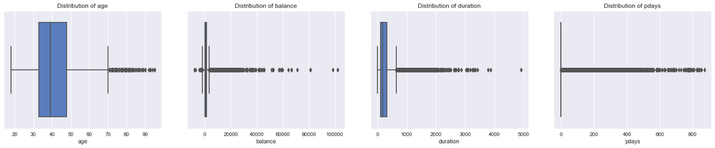

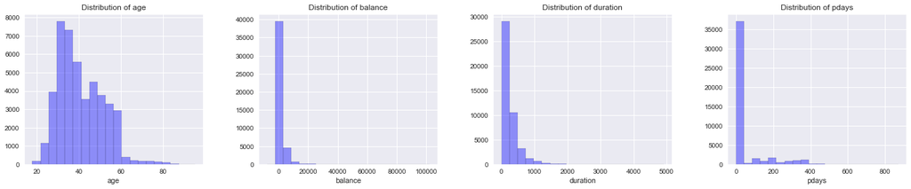

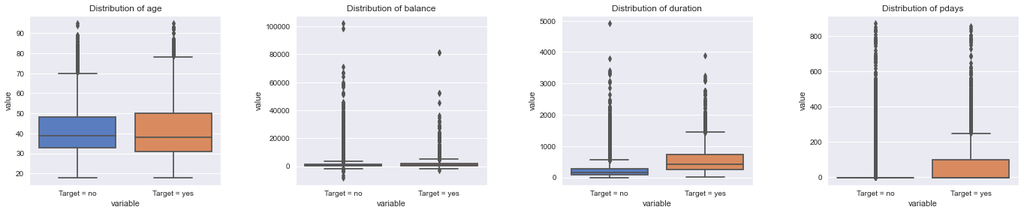

```python
num_plots = len(numeric_columns_1)
total_cols = 4
total_rows = 1
fig, axs = plt.subplots(nrows=total_rows, ncols=total_cols, figsize=(20, 5))
for i, var in enumerate(numeric_columns_1):
    pos = i % total_cols
    ax = sns.boxplot(bank_mark_df[var], ax=axs[pos])
    ax.set_title("Distribution of {0}".format(var))
fig.tight_layout(pad=4.5)
plt.show();

fig, axs = plt.subplots(nrows=total_rows, ncols=total_cols, figsize=(20, 5))
for i, var in enumerate(numeric_columns_1):
    pos = i % total_cols
    ax = sns.distplot(bank_mark_df[var], color="blue", kde_kws={"color": "m", "lw": 2}, hist_kws={'edgecolor':'black'}, ax=axs[pos], bins=20, kde=False)
    ax.set_title("Distribution of {0}".format(var))
fig.tight_layout(pad=4.5)
plt.show();

fig, axs = plt.subplots(nrows=total_rows, ncols=total_cols, figsize=(20, 5))
for i, var in enumerate(numeric_columns_1):
    not_taken_personal_loan = bank_mark_df[bank_mark_df["Target"] == "no"][var]
    taken_personal_loan = bank_mark_df[bank_mark_df["Target"] == "yes"][var]
    df = pd.DataFrame({'Target = no': not_taken_personal_loan, 'Target = yes': taken_personal_loan})
    pos = i % total_cols
    ax = sns.boxplot(x="variable", y="value", data=pd.melt(df), ax=axs[pos])
    ax.set_title("Distribution of {0}".format(var))
fig.tight_layout(pad=4.5)
plt.show();
```

##### Observation

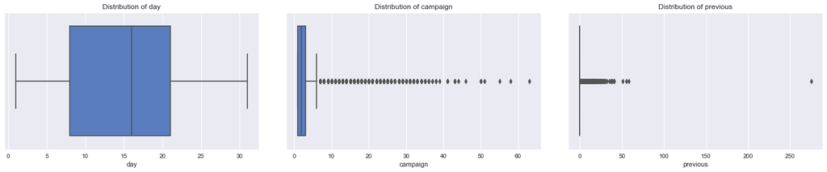

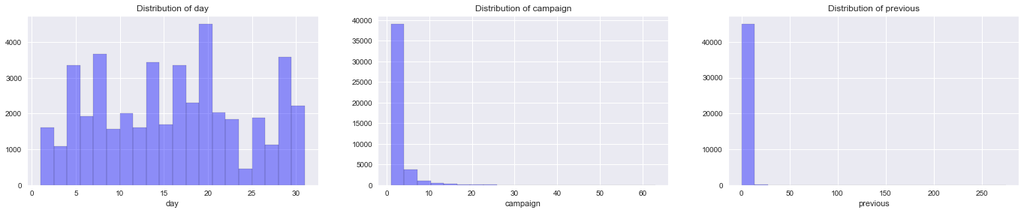

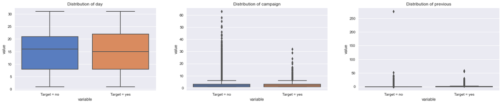

```python
num_plots = len(numeric_columns_2)
total_cols = 3
total_rows = 1
fig, axs = plt.subplots(nrows=total_rows, ncols=total_cols, figsize=(20, 5))
for i, var in enumerate(numeric_columns_2):
    pos = i % total_cols
    ax = sns.boxplot(bank_mark_df[var], ax=axs[pos])
    ax.set_title("Distribution of {0}".format(var))
fig.tight_layout(pad=4.5)
plt.show();

fig, axs = plt.subplots(nrows=total_rows, ncols=total_cols, figsize=(20, 5))
for i, var in enumerate(numeric_columns_2):
    pos = i % total_cols
    ax = sns.distplot(bank_mark_df[var], color="blue", kde_kws={"color": "m", "lw": 2}, hist_kws={'edgecolor':'black'}, ax=axs[pos], bins=20, kde=False)
    ax.set_title("Distribution of {0}".format(var))
fig.tight_layout(pad=4.5)
plt.show();

fig, axs = plt.subplots(nrows=total_rows, ncols=total_cols, figsize=(20, 5))
for i, var in enumerate(numeric_columns_2):
    not_taken_personal_loan = bank_mark_df[bank_mark_df["Target"] == "no"][var]
    taken_personal_loan = bank_mark_df[bank_mark_df["Target"] == "yes"][var]
    df = pd.DataFrame({'Target = no': not_taken_personal_loan, 'Target = yes': taken_personal_loan})
    pos = i % total_cols
    ax = sns.boxplot(x="variable", y="value", data=pd.melt(df), ax=axs[pos])
    ax.set_title("Distribution of {0}".format(var))
fig.tight_layout(pad=4.5)
plt.show();
```

##### Observation

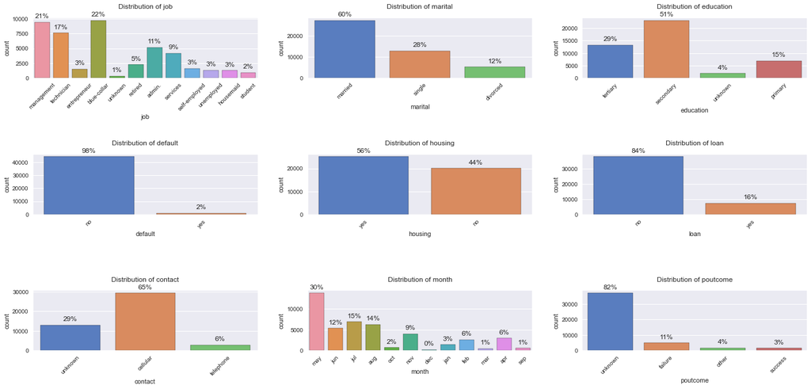

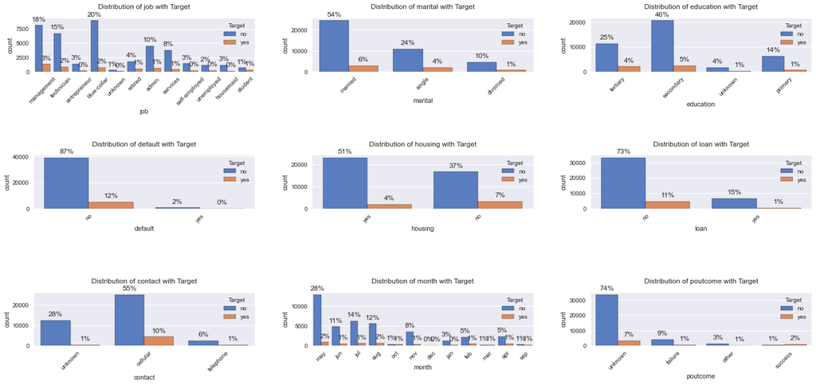

```python
cat_count_plot_columns = ["job", "marital", "education", "default", "housing", "loan", "contact", "month", "poutcome"]
num_plots = len(cat_count_plot_columns)
total_cols = 3
total_rows = 3
fig, axs = plt.subplots(nrows=total_rows, ncols=total_cols, figsize=(20, 10))
for i, var in enumerate(cat_count_plot_columns):
    row = i//total_cols
    pos = i % total_cols
    ax = sns.countplot(bank_mark_df[var], edgecolor="black", ax=axs[row][pos])
    total = len(bank_mark_df[var])
    for p in ax.patches:
        percentage = '{:.0f}%'.format(100 * p.get_height()/total)
        x = p.get_x() + 0.4
        y = p.get_y() + p.get_height()
        ax.annotate(percentage, (x,y), size = 12, ha = 'center', va = 'center', xytext = (0, 10), textcoords = 'offset points')
    ax.set_title("Distribution of {0}".format(var), pad=15)
    ax.set_xticklabels(ax.get_xticklabels(), rotation=45)
# axs[1,2].set_axis_off()
fig.tight_layout(pad=3.5)
plt.show();


fig, axs = plt.subplots(nrows=total_rows, ncols=total_cols, figsize=(20, 10))
for i, var in enumerate(cat_count_plot_columns):
    row = i//total_cols
    pos = i % total_cols
    ax = sns.countplot(x=var, hue="Target", data=bank_mark_df, edgecolor="black", ax=axs[row][pos])
    total = len(bank_mark_df[var])
    for p in ax.patches:
        percentage = '{:.0f}%'.format(100 * p.get_height()/total)
        x = p.get_x() + 0.2
        y = p.get_y() + p.get_height()
        ax.annotate(percentage, (x,y), size = 12, ha = 'center', va = 'center', xytext = (0, 10), textcoords = 'offset points')
    ax.set_title("Distribution of {0} with Target".format(var), pad=15)
    ax.set_xticklabels(ax.get_xticklabels(), rotation=45)
# axs[1,2].set_axis_off()
fig.tight_layout(pad=4.5)
plt.show();
```

##### Observation

- Columns **job**, **education**, **contact**, **poutcome** have **unknown** values, which will require special handling
- **job** - Majority of customers are in **blue-collar (22%)** and **management (21%)** jobs
  - When considered along with "Target", **blue-collar** and **management** jobs again have more subscriptions.
- **marital** - Majority of customers are **married (60%)**
  - When considered along with "Target", **married** customers have more subscriptions.
- **education** - Majority of customers have **secondary (51%)** education level
  - When considered along with "Target", **secondary** education level customer have more subscriptions.
- **default** - Majority of customers dont have a credit default **(98%)**
  - **12%** of customers with no default ended up with a subscription.
- **housing** - Majority of customers have housing loan **(56%)**
  - **7%** of customers with no housing loan ended up with a subscription
- **loan** - Majority of customers dont have a personal loan **(84%)**
  - **11%** of customers with no personal loan ended up with a subscription
- **contact** - Majority of customers were contacted via cellular **(65%)**
  - **10%** of customers contacted via cellular ended up with a subscription
- **month** - Majority of customers were last contacted in May **(30%)**
  - When considered with "Target", May and Aug seems to be preferable with **2%**
- **poutcome** - Majority of customers have **unknown** poutcome

### Strategies to handle data challenges

#### Data Pollution

- The columns under consideration for data pollution are **balance** and **pdays**
- **balance** - We notice some negative values for balance.
  - **Negative Balance** - If there are customers with negative balance and have subscribed to Term Deposit, we can safely assume its a data entry error. Its highly unlikely a bank would allow a customer with negative balance to subscribe. A term deposit would require a lock in capital and with negative balance it is not possible. So for those values, we can take the absolute of them to fix it.
  - **Zero Balance** - Again based on above logic, if there are customers with zero balance and have subscribed to Term Deposit, we can assume its a data entry error. But for this case, we will replace it with median balance.
  - **Low Balance** - Even after replacing the values, there might be instances where the balance is very low (Eg: **1**). But without knowing what was the agreed term deposit amount, its difficult to fix these values. So for the purpose of this project, we will just allow these values to be as is.
- **pdays** - We notice negative value (**-1**) for most of customers. This just means these customers were never contacted or contact period has been more than 900 days. So for these values, we can convert all the **-1** to **900**, which is the max pdays we are considering

#### Outliers

- The columns under consideration for outliers are **age**, **balance**, **duration**, **pdays**, **campaign** and **previous**
- **age** - We can attempt to bin the values for age to reduce the effect of outliers
- **balance** - We can log transform the value, to pull in the outliers
- **duration** - We can log transform the value, to pull in the outliers
- **pdays** - We can log transform the value, to pull in the outliers
- **campaign** - We can log transform the value, to pull in the outliers
- **previous** - We can log transform the value, to pull in the outliers

#### Missing Values

- The columns under consideration for missing values are the categorical columns **job**, **education**, **contact** and **poutcome**
- For all the categorical columns, we can replace the missing "unknown" values with the mode of the column.

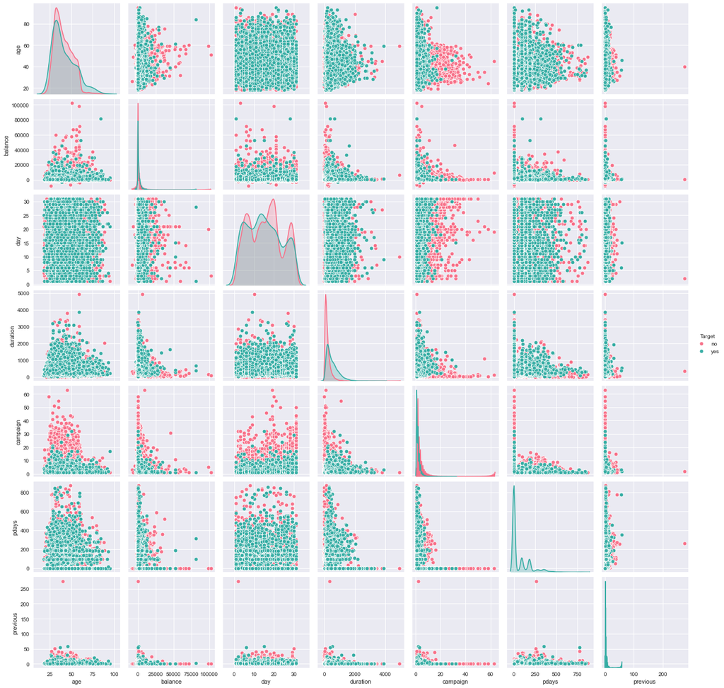

```python
sns.pairplot(bank_mark_df,diag_kind='kde', hue="Target", palette="husl")
plt.show();
```

##### Observation

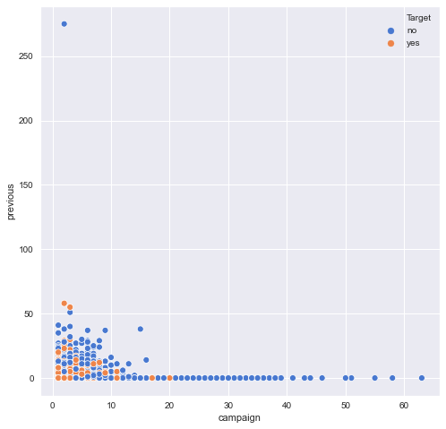

```python
plt.figure(figsize = (8,8))
sns.scatterplot(x="campaign", y="previous", hue="Target", data=bank_mark_df)
plt.show();
```

##### Observation

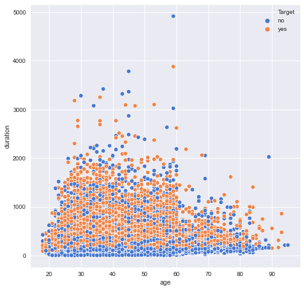

```python
# numeric_columns = ["age", "balance", "day", "duration", "campaign", "pdays", "previous"]
# cat_count_plot_columns = ["job", "marital", "education", "default", "housing", "loan", "contact", "month", "poutcome"]

plt.figure(figsize = (8,8))
sns.scatterplot(x="age", y="duration", hue="Target", data=bank_mark_df)
plt.show();
```

##### Observation

- As **age** increases, the duration for customers who subscribed to Term Deposit stays between **100-800**

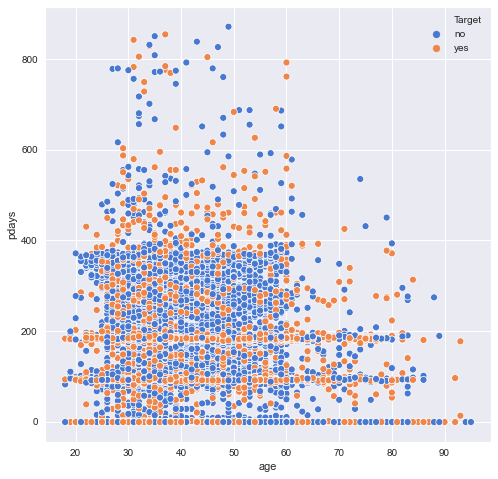

```python
plt.figure(figsize = (8,8))
sns.scatterplot(x="age", y="pdays", hue="Target", data=bank_mark_df)
plt.show();
```

##### Observation

- As **age** increases, the **pdays** is between **0-200** days

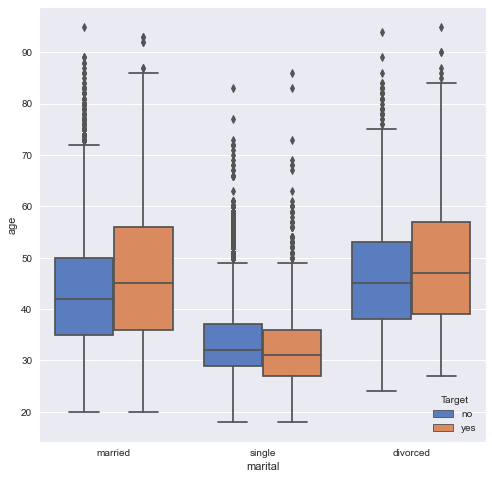

```python
plt.figure(figsize = (8,8))
sns.boxplot(x="marital", y="age", hue="Target", data=bank_mark_df)
plt.show();
```

##### Observation

- **married**
  - "Target = no" - Age Ranges **35-50**
  - "Target = yes" - Age Ranges **36-57**
- **single**
  - "Target = no" - Age Ranges **28-38**
  - "Target = yes" - Age Ranges **27-36**
- **divorced**
  - "Target = no" - Age Ranges **38-54**
  - "Target = yes" - Age Ranges **39-57**

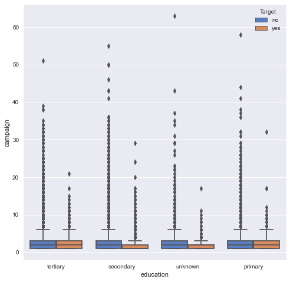

```python
plt.figure(figsize = (8,8))
sns.boxplot(x="education", y="campaign", hue="Target", data=bank_mark_df)
plt.show();
```

##### Observation

- For all education levels, looks like the number of contacts (campaign) is more or less the same. But it has a lot of outliers

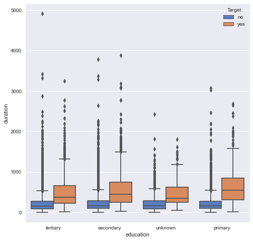

```python
plt.figure(figsize = (8,8))
sns.boxplot(x="education", y="duration", hue="Target", data=bank_mark_df)
plt.show();
```

##### Observation

- For all education levels, for "Target = no", the IQR is similar.
- For "Target = yes", the IQR range is wider for **primary** level

### Prepare data

#### Handle data pollution

##### balance column

```python
print("Number of customers with negative balance                                       : {0}".format(bank_mark_df[bank_mark_df["balance"] < 0].shape[0]))
print("Percentage of customers with negative balance                                   : {0:0.2f}%".format((bank_mark_df[bank_mark_df["balance"] < 0].shape[0] / bank_mark_df.shape[0]) * 100))
print("Percentage of customers who subscribed to a term deposit, with negative balance : {0:0.2f}%".format(bank_mark_df.loc[(bank_mark_df['Target'] == "yes") & (bank_mark_df["balance"] < 0)].shape[0] / bank_mark_df.loc[bank_mark_df['Target'] == "yes"].shape[0] * 100))
print("")
print("Number of customers with 0 balance                                              : {0}".format(bank_mark_df[bank_mark_df["balance"] == 0].shape[0]))
print("Percentage of customers with 0 balance                                          : {0:0.2f}%".format((bank_mark_df[bank_mark_df["balance"] == 0].shape[0] / bank_mark_df.shape[0]) * 100))
print("Percentage of customers who subscribed to a term deposit, with 0 balance        : {0:0.2f}%".format(bank_mark_df.loc[(bank_mark_df['Target'] == "yes") & (bank_mark_df["balance"] == 0)].shape[0] / bank_mark_df.loc[bank_mark_df['Target'] == "yes"].shape[0] * 100))
```

```
Number of customers with negative balance                                       : 3766
Percentage of customers with negative balance                                   : 8.33%
Percentage of customers who subscribed to a term deposit, with negative balance : 3.97%

Number of customers with 0 balance                                              : 3514
Percentage of customers with 0 balance                                          : 7.77%
Percentage of customers who subscribed to a term deposit, with 0 balance        : 5.52%
```

```python
bank_mark_df['balance'] = bank_mark_df['balance'].abs()

cust_with_valid_balance = bank_mark_df[bank_mark_df["balance"] > 0]
median_valid_balance = cust_with_valid_balance["balance"].median()

print("")
print("Replacing invalid balance with Median             : {0}".format(median_valid_balance))

# Replace invalid experience with Median (20)
bank_mark_df.loc[bank_mark_df["balance"] == 0, "balance"] = median_valid_balance


display(HTML(bank_mark_df.describe().T.to_html()))
```

```
Replacing invalid balance with Median             : 565.0
```

|  | count | mean | std | min | 25% | 50% | 75% | max |
| --- | --- | --- | --- | --- | --- | --- | --- | --- |
| age | 45211.0 | 40.936210 | 10.618762 | 18.0 | 33.0 | 39.0 | 48.0 | 95.0 |
| balance | 45211.0 | 1459.110393 | 3003.695568 | 1.0 | 225.0 | 565.0 | 1436.0 | 102127.0 |
| day | 45211.0 | 15.806419 | 8.322476 | 1.0 | 8.0 | 16.0 | 21.0 | 31.0 |
| duration | 45211.0 | 258.163080 | 257.527812 | 0.0 | 103.0 | 180.0 | 319.0 | 4918.0 |
| campaign | 45211.0 | 2.763841 | 3.098021 | 1.0 | 1.0 | 2.0 | 3.0 | 63.0 |
| pdays | 45211.0 | 40.197828 | 100.128746 | -1.0 | -1.0 | -1.0 | -1.0 | 871.0 |
| previous | 45211.0 | 0.580323 | 2.303441 | 0.0 | 0.0 | 0.0 | 0.0 | 275.0 |

##### pdays column

```python
print("Replacing all -1 pdays to 900")
bank_mark_df.loc[bank_mark_df["pdays"] == -1, "pdays"] = 900

display(HTML(bank_mark_df.describe().T.to_html()))
```

```
Replacing all -1 pdays to 900
```

|  | count | mean | std | min | 25% | 50% | 75% | max |
| --- | --- | --- | --- | --- | --- | --- | --- | --- |
| age | 45211.0 | 40.936210 | 10.618762 | 18.0 | 33.0 | 39.0 | 48.0 | 95.0 |
| balance | 45211.0 | 1459.110393 | 3003.695568 | 1.0 | 225.0 | 565.0 | 1436.0 | 102127.0 |
| day | 45211.0 | 15.806419 | 8.322476 | 1.0 | 8.0 | 16.0 | 21.0 | 31.0 |
| duration | 45211.0 | 258.163080 | 257.527812 | 0.0 | 103.0 | 180.0 | 319.0 | 4918.0 |
| campaign | 45211.0 | 2.763841 | 3.098021 | 1.0 | 1.0 | 2.0 | 3.0 | 63.0 |
| pdays | 45211.0 | 776.645905 | 265.576597 | 1.0 | 900.0 | 900.0 | 900.0 | 900.0 |
| previous | 45211.0 | 0.580323 | 2.303441 | 0.0 | 0.0 | 0.0 | 0.0 | 275.0 |

#### Handle outliers

##### age column

Since age has Q1 = 33, Q2 = 39, Q3 = 48, we can bin the age into 4 buckets, viz: 1-30, 31-40, 41-50. 51-100 (max is 95)

```python
age_bin_edges = [1, 30, 40, 50, 100] # edges to define intervals
age_bin_labels = ['1-30', '31-40', '41-50','51-100'] # labels to denote each interval
bank_mark_df["age"] = pd.cut(bank_mark_df["age"], bins=age_bin_edges , labels=age_bin_labels)
```

```python
bank_mark_df["age"].value_counts(normalize=True)*100
```

```
31-40     39.121010
41-50     24.858994
51-100    20.470682
1-30      15.549313
Name: age, dtype: float64
```

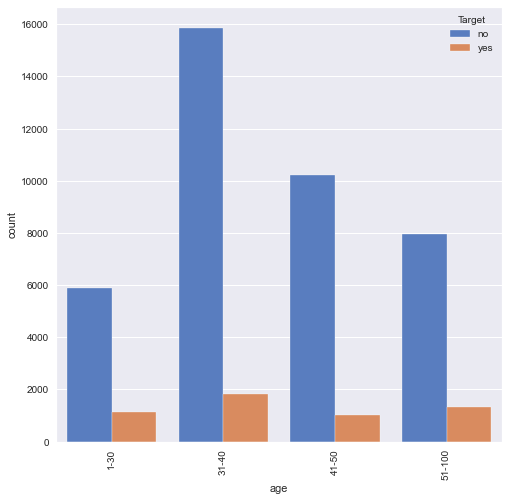

```python
plt.figure(figsize=(8,8))
sns.countplot(x = "age",data=bank_mark_df,hue="Target")
plt.xticks(rotation=90) # to rotate labels of x-axis
plt.show();
```

##### balance column

Since balance as Q1=225.0, Q2=565.0, Q3=1436.0 and max = 102127.0, we can use that to bin the data

```python
balance_bin_edges = [0, 225, 565, 1436, 102127] # edges to define intervals
balance_bin_labels = ['0-225', '226-565', '566-1436','1437-102127'] # labels to denote each interval
bank_mark_df["balance"] = pd.cut(bank_mark_df["balance"], bins=balance_bin_edges , labels=balance_bin_labels)
```

```python
bank_mark_df["balance"].value_counts(normalize=True)*100
```

```
226-565        28.866869
0-225          25.027095
1437-102127    24.998341
566-1436       21.107695
Name: balance, dtype: float64
```

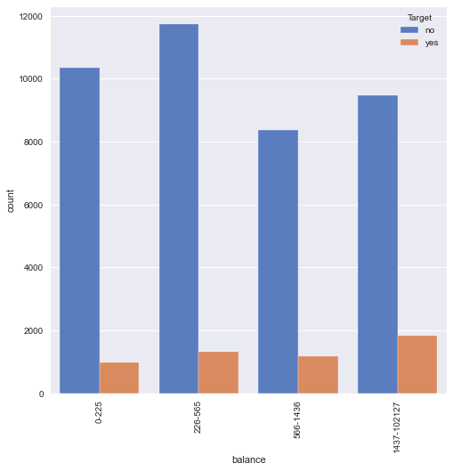

```python
plt.figure(figsize=(8,8))
sns.countplot(x = "balance",data=bank_mark_df,hue="Target")
plt.xticks(rotation=90) # to rotate labels of x-axis
plt.show();
```

#### Handle missing data

Some of the categorical columns have "unknown" as their value. Lets discuss how to address them. As much as possible, we will try not to remove rows with invalid values, so as not to loose information from other columns

#### rows with "unknown" for all categorical columns

For starters, we can look at rows that have unknown for all the 4 categorical columns we are going to discuss here.

```python
print("Number of customers with \"unknown\" for all the categorical columns considered", bank_mark_df.loc[(bank_mark_df["job"] == "unknown") & (bank_mark_df["education"] == "unknown") & (bank_mark_df["contact"] == "unknown") & (bank_mark_df["poutcome"] == "unknown")].shape[0])
```

```
Number of customers with "unknown" for all the categorical columns considered 54
```

Since this is a very small size, we can remove them from the dataset

```python
bank_mark_df.drop(bank_mark_df[(bank_mark_df["job"] == "unknown") & (bank_mark_df["education"] == "unknown") & (bank_mark_df["contact"] == "unknown") & (bank_mark_df["poutcome"] == "unknown")].index, inplace=True)
print("Number of customers with \"unknown\" for all the categorical columns considered", bank_mark_df.loc[(bank_mark_df["job"] == "unknown") & (bank_mark_df["education"] == "unknown") & (bank_mark_df["contact"] == "unknown") & (bank_mark_df["poutcome"] == "unknown")].shape[0])
```

```
Number of customers with "unknown" for all the categorical columns considered 0
```

#### "job" column

```python
print("")
print("Total number of customers in the data                                        : {0}".format(bank_mark_df.shape[0]))
print("Total number of customers with \"unknown\" job                                 : {0}".format(bank_mark_df[bank_mark_df["job"] == "unknown"].shape[0]))
print("Percentage of customer with \"unknown\" job                                    : {0:0.2f}%".format((bank_mark_df[bank_mark_df["job"] == "unknown"].shape[0] / bank_mark_df.shape[0]) * 100))
print("Percentage of customers who subscribed to a term deposit, with \"unknown\" job : {0:0.2f}%".format(bank_mark_df.loc[(bank_mark_df["Target"] == "yes") & (bank_mark_df["job"] == "unknown")].shape[0] / bank_mark_df.loc[bank_mark_df['Target'] == "yes"].shape[0] * 100))
```

```
Total number of customers in the data                                        : 45157
Total number of customers with "unknown" job                                 : 234
Percentage of customer with "unknown" job                                    : 0.52%
Percentage of customers who subscribed to a term deposit, with "unknown" job : 0.62%
```

Since its a very small percentage, we can try replacing "unknown" jobs with the mode of the jobs column ("blue-collar")

```python
cust_with_valid_job = bank_mark_df[bank_mark_df["job"] != "unknown"]
mode_valid_job = cust_with_valid_job["job"].mode()

print("Replacing invalid job with Mode    : ", mode_valid_job[0])

# Replace invalid job with Mode
bank_mark_df.loc[bank_mark_df["job"] == "unknown", "job"] = mode_valid_job[0]
print("")
print(bank_mark_df["job"].value_counts(normalize=True) * 100)
```

```
Replacing invalid job with Mode    :  blue-collar

blue-collar      22.069668
management       20.944704
technician       16.823527
admin.           11.451159
services          9.199017
retired           5.013619
self-employed     3.496689
entrepreneur      3.292956
unemployed        2.885488
housemaid         2.745975
student           2.077197
Name: job, dtype: float64
```

#### "education" column

```python
print("")
print("Total number of customers in the data                                              : {0}".format(bank_mark_df.shape[0]))
print("Total number of customers with \"unknown\" education                                 : {0}".format(bank_mark_df[bank_mark_df["education"] == "unknown"].shape[0]))
print("Percentage of customer with \"unknown\" education                                    : {0:0.2f}%".format((bank_mark_df[bank_mark_df["education"] == "unknown"].shape[0] / bank_mark_df.shape[0]) * 100))
print("Percentage of customers who subscribed to a term deposit, with \"unknown\" education : {0:0.2f}%".format(bank_mark_df.loc[(bank_mark_df["Target"] == "yes") & (bank_mark_df["education"] == "unknown")].shape[0] / bank_mark_df.loc[bank_mark_df['Target'] == "yes"].shape[0] * 100))
```

```
Total number of customers in the data                                              : 45157
Total number of customers with "unknown" education                                 : 1803
Percentage of customer with "unknown" education                                    : 3.99%
Percentage of customers who subscribed to a term deposit, with "unknown" education : 4.75%
```

We can try to replace with the mode of the education column as majority of the customers considered seem to have "secondary" education level.

```python
cust_with_valid_education = bank_mark_df[bank_mark_df["education"] != "unknown"]
mode_valid_education = cust_with_valid_education["education"].mode()

print("Replacing invalid education with Mode    : ", mode_valid_education[0])

# Replace invalid education with Mode
bank_mark_df.loc[bank_mark_df["education"] == "unknown", "education"] = mode_valid_education[0]
print("")
print(bank_mark_df["education"].value_counts(normalize=True) * 100)
```

```
Replacing invalid education with Mode    :  secondary

secondary    55.373475
tertiary     29.455013
primary      15.171513
Name: education, dtype: float64
```

#### "contact" column

```python
print("")
print("Total number of customers in the data                                              : {0}".format(bank_mark_df.shape[0]))
print("Total number of customers with \"unknown\" contact                                 : {0}".format(bank_mark_df[bank_mark_df["contact"] == "unknown"].shape[0]))
print("Percentage of customer with \"unknown\" contact                                    : {0:0.2f}%".format((bank_mark_df[bank_mark_df["contact"] == "unknown"].shape[0] / bank_mark_df.shape[0]) * 100))
print("Percentage of customers who subscribed to a term deposit, with \"unknown\" contact : {0:0.2f}%".format(bank_mark_df.loc[(bank_mark_df["Target"] == "yes") & (bank_mark_df["contact"] == "unknown")].shape[0] / bank_mark_df.loc[bank_mark_df['Target'] == "yes"].shape[0] * 100))
```

```
Total number of customers in the data                                              : 45157
Total number of customers with "unknown" contact                                 : 12966
Percentage of customer with "unknown" contact                                    : 28.71%
Percentage of customers who subscribed to a term deposit, with "unknown" contact : 10.00%
```

Considering that the valid values for contact are either "telephone" or "cellular", both being a phone medium, we can use the mode (cellular) of the column for replacement.

```python
cust_with_valid_contact = bank_mark_df[bank_mark_df["contact"] != "unknown"]
mode_valid_contact = cust_with_valid_contact["contact"].mode()

print("Replacing invalid contact with Mode    : ", mode_valid_contact[0])

# Replace invalid contact with Mode
bank_mark_df.loc[bank_mark_df["contact"] == "unknown", "contact"] = mode_valid_contact[0]
print("")
print(bank_mark_df["contact"].value_counts(normalize=True) * 100)
```

```
Replacing invalid contact with Mode    :  cellular

cellular     93.564674
telephone     6.435326
Name: contact, dtype: float64
```

```python
bank_mark_df['job'] = bank_mark_df['job'].astype('category')
bank_mark_df['marital'] = bank_mark_df['marital'].astype('category')
bank_mark_df['education'] = bank_mark_df['education'].astype('category')
bank_mark_df['default'] = bank_mark_df['default'].astype('category')
bank_mark_df['housing'] = bank_mark_df['housing'].astype('category')
bank_mark_df['loan'] = bank_mark_df['loan'].astype('category')
bank_mark_df['contact'] = bank_mark_df['contact'].astype('category')
bank_mark_df['month'] = bank_mark_df['month'].astype('category')
bank_mark_df['poutcome'] = bank_mark_df['poutcome'].astype('category')
bank_mark_df['Target'] = bank_mark_df['Target'].astype('category')
```

```python
print(bank_mark_df.info())
```

```
<class 'pandas.core.frame.DataFrame'>
Int64Index: 45157 entries, 0 to 45210
Data columns (total 17 columns):
 #   Column     Non-Null Count  Dtype
---  ------     --------------  -----
 0   age        45157 non-null  category
 1   job        45157 non-null  category
 2   marital    45157 non-null  category
 3   education  45157 non-null  category
 4   default    45157 non-null  category
 5   balance    45157 non-null  category
 6   housing    45157 non-null  category
 7   loan       45157 non-null  category
 8   contact    45157 non-null  category
 9   day        45157 non-null  int64
 10  month      45157 non-null  category
 11  duration   45157 non-null  int64
 12  campaign   45157 non-null  int64
 13  pdays      45157 non-null  int64
 14  previous   45157 non-null  int64
 15  poutcome   45157 non-null  category
 16  Target     45157 non-null  category
dtypes: category(12), int64(5)
memory usage: 2.6 MB
None
```

```python
# Label encode the binned values (as ordering is already done)
bank_mark_df['age'] = bank_mark_df['age'].cat.codes
bank_mark_df['balance'] = bank_mark_df['balance'].cat.codes
```

```python
replaceStruct={"education": {"primary": 1, "secondary": 2 ,"tertiary": 3},  # education is ordered lower to higher levels (ordinal)",
               "default": {"yes": 1, "no":2}, # having a credit default is considered ordinal",
               "housing": {"yes": 1, "no":2}, # having a housing loan is considered ordinal",
               "loan": {"yes": 1, "no": 2}, # having personal loan is considered ordinal",
               "Target": {"no": 0, "yes": 1} # target is converted to binary"
              }
oneHotCols=["job","marital","contact", "month", "poutcome"] # one hot encode other columns
```

```python
bank_mark_df=bank_mark_df.replace(replaceStruct)
```

```python
# One hot encode the required columns
bank_mark_df=pd.get_dummies(bank_mark_df, drop_first=True, columns=oneHotCols)
```

```python
display(HTML(bank_mark_df.head(10).to_html()))
```

|  | age | education | default | balance | housing | loan | day | duration | campaign | pdays | previous | Target | job_blue-collar | job_entrepreneur | job_housemaid | job_management | job_retired | job_self-employed | job_services | job_student | job_technician | job_unemployed | marital_married | marital_single | contact_telephone | month_aug | month_dec | month_feb | month_jan | … |
| --- | --- | --- | --- | --- | --- | --- | --- | --- | --- | --- | --- | --- | --- | --- | --- | --- | --- | --- | --- | --- | --- | --- | --- | --- | --- | --- | --- | --- | --- | --- |
| 0 | 3 | 3 | 2 | 3 | 1 | 2 | 5 | 261 | 1 | 900 | 0 | 0 | 0 | 0 | 0 | 1 | 0 | 0 | 0 | 0 | 0 | 0 | 1 | 0 | 0 | 0 | 0 | 0 | 0 | … |
| 1 | 2 | 2 | 2 | 0 | 1 | 2 | 5 | 151 | 1 | 900 | 0 | 0 | 0 | 0 | 0 | 0 | 0 | 0 | 0 | 0 | 1 | 0 | 0 | 1 | 0 | 0 | 0 | 0 | 0 | … |
| 2 | 1 | 2 | 2 | 0 | 1 | 1 | 5 | 76 | 1 | 900 | 0 | 0 | 0 | 1 | 0 | 0 | 0 | 0 | 0 | 0 | 0 | 0 | 1 | 0 | 0 | 0 | 0 | 0 | 0 | … |
| 3 | 2 | 2 | 2 | 3 | 1 | 2 | 5 | 92 | 1 | 900 | 0 | 0 | 1 | 0 | 0 | 0 | 0 | 0 | 0 | 0 | 0 | 0 | 1 | 0 | 0 | 0 | 0 | 0 | 0 | … |
| 5 | 1 | 3 | 2 | 1 | 1 | 2 | 5 | 139 | 1 | 900 | 0 | 0 | 0 | 0 | 0 | 1 | 0 | 0 | 0 | 0 | 0 | 0 | 1 | 0 | 0 | 0 | 0 | 0 | 0 | … |
| 6 | 0 | 3 | 2 | 1 | 1 | 1 | 5 | 217 | 1 | 900 | 0 | 0 | 0 | 0 | 0 | 1 | 0 | 0 | 0 | 0 | 0 | 0 | 0 | 1 | 0 | 0 | 0 | 0 | 0 | … |
| 7 | 2 | 3 | 1 | 0 | 1 | 2 | 5 | 380 | 1 | 900 | 0 | 0 | 0 | 1 | 0 | 0 | 0 | 0 | 0 | 0 | 0 | 0 | 0 | 0 | 0 | 0 | 0 | 0 | 0 | … |
| 8 | 3 | 1 | 2 | 0 | 1 | 2 | 5 | 50 | 1 | 900 | 0 | 0 | 0 | 0 | 0 | 0 | 1 | 0 | 0 | 0 | 0 | 0 | 1 | 0 | 0 | 0 | 0 | 0 | 0 | … |
| 9 | 2 | 2 | 2 | 2 | 1 | 2 | 5 | 55 | 1 | 900 | 0 | 0 | 0 | 0 | 0 | 0 | 0 | 0 | 0 | 0 | 1 | 0 | 0 | 1 | 0 | 0 | 0 | 0 | 0 | … |
| 10 | 2 | 2 | 2 | 1 | 1 | 2 | 5 | 222 | 1 | 900 | 0 | 0 | 0 | 0 | 0 | 0 | 0 | 0 | 0 | 0 | 0 | 0 | 0 | 0 | 0 | 0 | 0 | 0 | 0 | … |

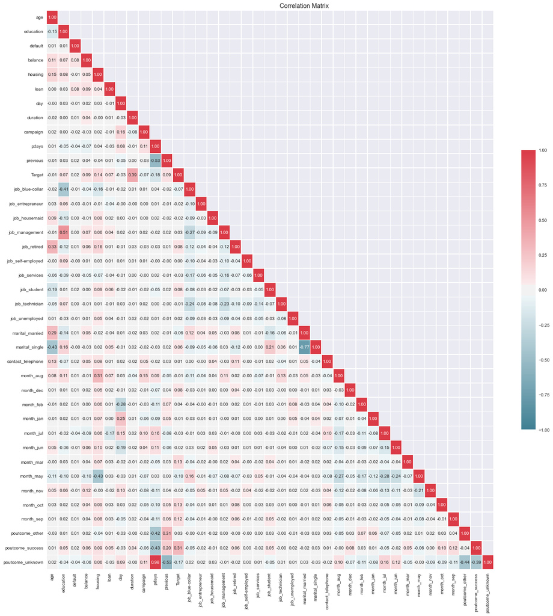

```python
# Graphical representation of the correlation
correlation = bank_mark_df.corr()

# Generate a custom diverging colormap
cmap = sns.diverging_palette(220, 10, as_cmap=True)

fig_corr, axes_corr = plt.subplots(nrows=1, ncols=1, figsize=(20,20))

# Hide the upper half of the matrix - So that we see the values only once
mask = np.zeros_like(correlation)
mask[np.triu_indices_from(mask, 1)] = True
sns.heatmap(correlation, ax=axes_corr,  linewidths=.5, cbar_kws={"shrink": .5}, cmap=cmap, vmin=-1, annot=True, fmt=".2f", mask=mask)
fig_corr.suptitle("Correlation Matrix", fontsize=14)
plt.yticks(fontsize=10, va="center")
fig_corr.tight_layout(pad=4.5)
plt.show();
```

##### Observation

- Based on the correlation matrix above, we can see that **age**, **default** and **day** have very low correlation with **Target**. So we can investigate if removing these columns improves the performance of the model

```python
# Let us look at the target column which is 'Personal Loan' to understand how the data is distributed amongst the various values
display(HTML(bank_mark_df.groupby(["Target"]).mean().to_html()))
```

| Target | age | education | default | balance | housing | loan | day | duration | campaign | pdays | previous | job_blue-collar | job_entrepreneur | job_housemaid | job_management | job_retired | job_self-employed | job_services | job_student | job_technician | job_unemployed | marital_married | marital_single | contact_telephone | month_aug | month_dec | month_feb | month_jan | month_jul | … |
| --- | --- | --- | --- | --- | --- | --- | --- | --- | --- | --- | --- | --- | --- | --- | --- | --- | --- | --- | --- | --- | --- | --- | --- | --- | --- | --- | --- | --- | --- | --- |
| 0 | 1.505531 | 2.126539 | 1.980887 | 1.425719 | 1.418345 | 1.830445 | 15.895533 | 221.203968 | 2.846046 | 793.922195 | 0.502822 | 0.231383 | 0.034212 | 0.028368 | 0.204595 | 0.043844 | 0.034914 | 0.094936 | 0.01678 | 0.16948 | 0.027615 | 0.612556 | 0.272543 | 0.063107 | 0.139432 | 0.002859 | 0.055381 | 0.031629 | 0.157215 | … |
| 1 | 1.472390 | 2.265696 | 1.990166 | 1.723525 | 1.634077 | 1.908472 | 15.156770 | 537.339259 | 2.141263 | 645.131241 | 1.170575 | 0.140129 | 0.023260 | 0.020613 | 0.246029 | 0.097579 | 0.035363 | 0.069781 | 0.05087 | 0.15885 | 0.038200 | 0.520802 | 0.361573 | 0.073752 | 0.130106 | 0.018911 | 0.083396 | 0.026853 | 0.118570 | … |

##### Observation

- From the mean values, we can see tha **Target** has higher dependency on **duration**, **previous**, **job_blue-collar**, **job_student**, **month_dec**, **month_mar**, **month_oct**, **month_sep**, **poutcome_success**

### Logistic Regression and Decision Trees

##### Discussion on Confusion Matrix Terms

- True Positive (TP) (Predicted = 1, Actual = 1)

  Predict that the customer will subscribe to Term Deposit, and they actually did.
- False Positive (FP) (Predicted = 1, Actual = 0)

  Predict that the customer will subscribe to Term Deposit, but they did not.
- True Negative (TN) (Predicted = 0, Actual = 0)

  Predict that the customer will not subscribe to Term Deposit, and they did not.
- False Negative (FN) (Predicted = 0, Actual = 1)

  Predict that the customer will not subscribe to Term Deposit, but they actually did.

##### Important Metric

The goal is to build a model that will help the marketing team identify potential customers who are relatively more likely to subscribe term deposit and thus increase their hit ratio.  
Based on this understanding, for this problem, the goal is to increase the number of potential customers that the marketing team can reach out to.  
Since the marketing team's hit ratio will go down if FN goes up, the goal is to reduce the number of FN. This is done by **improving Recall**.

So for any performance improvement, **Recall** will be the measure that is used for comparison.

```python
all_columns = bank_mark_df.columns.difference(["Target"])
```

```python
def split_data(description, df_to_use, target):
    print("Splitting data for                         : {0}".format(description))
    X = df_to_use
    Y = target
    X_train, X_test, y_train, y_test = train_test_split(X, Y, test_size=0.30, random_state=my_random_state)
    print("Original Term Deposit Subscribed Values     : {0} ({1:0.2f}%)".format(len(Y.loc[Y['Target'] == 1]), (len(Y.loc[Y['Target'] == 1])/len(Y.index)) * 100))
    print("Original Term Deposit Not Subscribed Values : {0} ({1:0.2f}%)".format(len(Y.loc[Y['Target'] == 0]), (len(Y.loc[Y['Target'] == 0])/len(Y.index)) * 100))
    print("")
    print("Training Term Deposit Subscribed Values     : {0} ({1:0.2f}%)".format(len(y_train[y_train['Target'] == 1]), (len(y_train[y_train['Target'] == 1])/len(y_train)) * 100))
    print("Training Term Deposit Not Subscribed Values : {0} ({1:0.2f}%)".format(len(y_train[y_train['Target'] == 0]), (len(y_train[y_train['Target'] == 0])/len(y_train)) * 100))
    print("")
    print("Test Term Deposit Subscribed Values         : {0} ({1:0.2f}%)".format(len(y_test[y_test['Target'] == 1]), (len(y_test[y_test['Target'] == 1])/len(y_test)) * 100))
    print("Test Term Deposit Not Subscribed Values     : {0} ({1:0.2f}%)".format(len(y_test[y_test['Target'] == 0]), (len(y_test[y_test['Target'] == 0])/len(y_test)) * 100))
    return (X_train, X_test, y_train, y_test)
```

```python
def create_confusion_matrix(axs, row, pos, description, actual, predicted, training_accuracy, testing_accuracy, precision, recall, f1_score, roc_auc_score):
    if axs.ndim > 1:
        axis_heat_map = axs[row][pos]
    else:
        axis_heat_map = axs[pos]

    labels = ["TN","FP","FN","TP"]
    cf = confusion_matrix( actual, predicted)
    group_labels = ["{}\n\n".format(value) for value in labels]
    group_counts = ["{0:0.0f}\n\n".format(value) for value in cf.flatten()]
    group_percentages = ["{0:.2%}".format(value) for value in cf.flatten()/np.sum(cf)]
    box_labels = [f"{v1}{v2}{v3}".strip() for v1, v2, v3 in zip(group_labels,group_counts,group_percentages)]
    box_labels = np.asarray(box_labels).reshape(cf.shape[0],cf.shape[1])

    stats_text = "\n\nAccuracy(Train) = {:0.3f}\nAccuracy(Test) = {:0.3f}\nPrecision = {:0.3f}\nRecall = {:0.3f}\nF1 Score = {:0.3f}\nROC AUC Score = {:0.3f}\n".format(training_accuracy, testing_accuracy, precision, recall, f1_score, roc_auc_score)

    heatmap = sns.heatmap(cf, annot=box_labels, annot_kws={"size": 14}, linewidths=0.5, linecolor='w', fmt="", cmap="Oranges", cbar=False, xticklabels="auto", yticklabels="auto", ax=axis_heat_map, square=True)
    axis_heat_map.set_title(description, fontsize=14)
    axis_heat_map.set_ylabel("Actual", fontsize=14)
    axis_heat_map.set_xlabel("Predicted" + stats_text, fontsize=14)
    axis_heat_map.set_xticklabels(axis_heat_map.get_xticklabels(), rotation = 45, fontsize = 10)
    axis_heat_map.set_yticklabels(axis_heat_map.get_yticklabels(), rotation = 25, fontsize = 10)

    return_list = [value for value in cf.flatten()]
    return return_list
```

```python
def train_test(axs, row, pos, description, df_to_use, target, algo):
    print("******************************** " + description + " ******************************************************")
    print("")
    X_train, X_test, y_train, y_test = split_data(description, df_to_use, target)
    algo.fit(X_train, y_train)
    y_predict = algo.predict(X_test)
    training_accuracy = algo.score(X_train,y_train)
    testing_accuracy = algo.score(X_test, y_test)
    precision = precision_score(y_test,y_predict)
    recall = recall_score(y_test,y_predict)
    f1score = f1_score(y_test,y_predict)
    rocscore = roc_auc_score(y_test,y_predict)

    cf_list = create_confusion_matrix(axs, row, pos, description, y_test, y_predict, training_accuracy, testing_accuracy, precision, recall, f1score, rocscore)

    return_list = [training_accuracy, testing_accuracy, precision, recall, f1score, rocscore]
    return_list = ["{:0.3f}".format(value) for value in return_list]
    return_list = cf_list + return_list
    return_list.insert(0, description)

    print("")
    print("********************************************************************************************************")


    return [X_train, X_test, y_train, y_test, algo, y_predict, return_list]
```

```python
def log_regression(axs, row, pos, description, df_to_use, target):
    logreg = LogisticRegression(random_state=my_random_state)
    return train_test(axs, row, pos, description, df_to_use, target, logreg)
```

```python
def decision_tree(axs, row, pos, description, df_to_use, target, max_depth):
    dt = DecisionTreeClassifier(criterion='entropy', random_state=my_random_state, max_depth=max_depth)
    return train_test(axs, row, pos, description, df_to_use, target, dt)
```

```python
def bagging(axs, row, pos, description, df_to_use, target, max_depth, logit=False, dt=True):
    if logit == True:
        bgcl = BaggingClassifier(base_estimator=LogisticRegression(random_state=my_random_state) ,n_estimators=50, max_samples= .7, bootstrap=True, oob_score=True, random_state=my_random_state)
    elif dt == True:
        bgcl = BaggingClassifier(base_estimator=DecisionTreeClassifier(criterion='entropy', max_depth=max_depth, random_state=my_random_state), n_estimators=50, max_samples= .7, bootstrap=True, oob_score=True, random_state=my_random_state)
    return train_test(axs, row, pos, description, df_to_use, target, bgcl)
```

```python
def random_forest(axs, row, pos, description, df_to_use, target, max_depth):
    rfcl = RandomForestClassifier(n_estimators = 50,random_state=my_random_state,max_depth=max_depth,criterion="entropy")
    return train_test(axs, row, pos, description, df_to_use, target, rfcl)
```

```python
def ada_boost(axs, row, pos, description, df_to_use, target, max_depth, logit=False, dt=True):
    if logit == True:
        abcl = AdaBoostClassifier(base_estimator=LogisticRegression(random_state=my_random_state), n_estimators = 50, learning_rate=0.1, random_state=my_random_state)
    elif dt == True:
        abcl = AdaBoostClassifier(base_estimator=DecisionTreeClassifier(criterion='entropy', max_depth=max_depth, random_state=my_random_state), n_estimators = 50, learning_rate=0.1, random_state=my_random_state)
    return train_test(axs, row, pos, description, df_to_use, target, abcl)
```

```python
def grad_boost(axs, row, pos, description, df_to_use, target, max_depth):
    gbcl = GradientBoostingClassifier(n_estimators = 50, learning_rate = 0.1, max_depth=max_depth,random_state=my_random_state)
    return train_test(axs, row, pos, description, df_to_use, target, gbcl)
```

```python
# Logistic Regression
experiments = {}

# EXP1: First we will test with all columns
exp1_df = bank_mark_df[all_columns]
experiments["Experiment 1"] = {
    "df": exp1_df,
    "target": bank_mark_df[["Target"]],
    "algo": "Logistic Regression",
    "description": "With all columns"
}

# EXP2: With "age", "default", "day" removed
lesser_columns = all_columns.difference(["age", "default", "day"])
exp2_df = bank_mark_df[lesser_columns]
experiments["Experiment 2"] = {
    "df": exp2_df,
    "target": bank_mark_df[["Target"]],
    "algo": "Logistic Regression",
    "description": "With age, default and day removed"
}
```

```
******************************** Logistic Regression: With all columns ******************************************************

Splitting data for                         : Logistic Regression: With all columns
Original Term Deposit Subscribed Values     : 5288 (11.71%)
Original Term Deposit Not Subscribed Values : 39869 (88.29%)

Training Term Deposit Subscribed Values     : 3648 (11.54%)
Training Term Deposit Not Subscribed Values : 27961 (88.46%)

Test Term Deposit Subscribed Values         : 1640 (12.11%)
Test Term Deposit Not Subscribed Values     : 11908 (87.89%)

******************************** Logistic Regression: With age, default and day removed ******************************************************

Splitting data for                         : Logistic Regression: With age, default and day removed
Original Term Deposit Subscribed Values     : 5288 (11.71%)
Original Term Deposit Not Subscribed Values : 39869 (88.29%)

Training Term Deposit Subscribed Values     : 3648 (11.54%)
Training Term Deposit Not Subscribed Values : 27961 (88.46%)

Test Term Deposit Subscribed Values         : 1640 (12.11%)
Test Term Deposit Not Subscribed Values     : 11908 (87.89%)
```

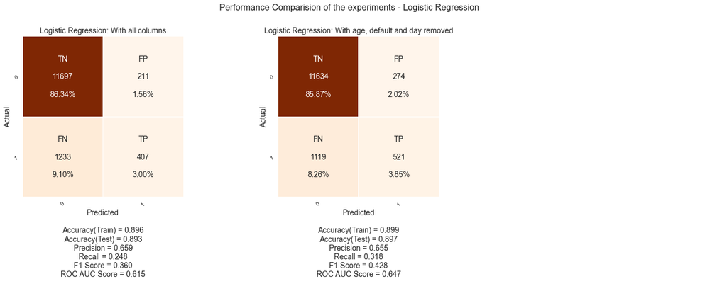

```python
num_plots = len(experiments.items())
total_cols = 3
total_rows = 1
fig_conf, axs = plt.subplots(nrows=total_rows, ncols=total_cols, figsize=(20,7))

exp_result = {}
all_results = {}
for i, (exp_k, exp_v) in enumerate(experiments.items()):
    row = i//total_cols
    pos = i % total_cols

    exp_data = log_regression(axs, row, pos, exp_v["algo"] + ": " + exp_v["description"], exp_v["df"], exp_v["target"])
    exp_result[i] = exp_data[6]
    all_results[i] = exp_data

axs[2].set_axis_off()
fig_conf.tight_layout(pad=3.5)
fig_conf.suptitle("Performance Comparision of the experiments - Logistic Regression", fontsize=16, y=1.05)
plt.show();
```

```python
exp_result_df = pd.DataFrame.from_dict(exp_result, orient="index", columns=["Description", "TN","FP","FN","TP", "Training Accuracy", "Testing Accuracy", "Precision", "Recall", "F1 Score", "ROC AUC Score"])
exp_result_df_disp = exp_result_df.copy()
exp_result_df_disp.style.apply(lambda x: ['background: lightgreen' if x.name in [1] else '' for i in x], axis=1)
```

|  | Description | TN | FP | FN | TP | Training Accuracy | Testing Accuracy | Precision | Recall | F1 Score | ROC AUC Score |
| --- | --- | --- | --- | --- | --- | --- | --- | --- | --- | --- | --- |
| 0 | Logistic Regression: With all columns | 11697 | 211 | 1233 | 407 | 0.896 | 0.893 | 0.659 | 0.248 | 0.360 | 0.615 |
| 1 | Logistic Regression: With age, default and day removed | 11634 | 274 | 1119 | 521 | 0.899 | 0.897 | 0.655 | 0.318 | 0.428 | 0.647 |

##### Observation

Based on the values observed above - For Logistic Regression, based on the **Recall** score, the better model is **Logistic Regression: With age, default and day removed** with a **Recall = 0.318**. The TP has increased and FN as decreased as well.

```python
# Decision Tree
experiments = {}

# EXP1: First we will test with all columns
exp1_df = bank_mark_df[all_columns]
experiments["Experiment 1"] = {
    "df": exp1_df,
    "target": bank_mark_df[["Target"]],
    "algo": "Decision Tree",
    "max_depth": None,
    "description": "With all columns"
}

# EXP2: With "age", "default", "day" removed
lesser_columns = all_columns.difference(["age", "default", "day"])
exp2_df = bank_mark_df[lesser_columns]
experiments["Experiment 2"] = {
    "df": exp2_df,
    "target": bank_mark_df[["Target"]],
    "algo": "Decision Tree",
    "max_depth": None,
    "description": "With age, default and day removed"
}

# EXP3: all columns - regularized
exp3_df = bank_mark_df[all_columns]
experiments["Experiment 3"] = {
    "df": exp3_df,
    "target": bank_mark_df[["Target"]],
    "algo": "Decision Tree (Regularized - 4)",
    "max_depth": 4,
    "description": "With all columns"
}

# EXP2: With "age", "default", "day" removed - regularized
lesser_columns = all_columns.difference(["age", "default", "day"])
exp4_df = bank_mark_df[lesser_columns]
experiments["Experiment 4"] = {
    "df": exp4_df,
    "target": bank_mark_df[["Target"]],
    "algo": "Decision Tree (Regularized - 4)",
    "max_depth": 4,
    "description": "With age, default and day removed"
}
```

```
******************************** Decision Tree: With all columns ******************************************************

Splitting data for                         : Decision Tree: With all columns
Original Term Deposit Subscribed Values     : 5288 (11.71%)
Original Term Deposit Not Subscribed Values : 39869 (88.29%)

Training Term Deposit Subscribed Values     : 3648 (11.54%)
Training Term Deposit Not Subscribed Values : 27961 (88.46%)

Test Term Deposit Subscribed Values         : 1640 (12.11%)
Test Term Deposit Not Subscribed Values     : 11908 (87.89%)

******************************** Decision Tree: With age, default and day removed ******************************************************

Splitting data for                         : Decision Tree: With age, default and day removed
Original Term Deposit Subscribed Values     : 5288 (11.71%)
Original Term Deposit Not Subscribed Values : 39869 (88.29%)

Training Term Deposit Subscribed Values     : 3648 (11.54%)
Training Term Deposit Not Subscribed Values : 27961 (88.46%)

Test Term Deposit Subscribed Values         : 1640 (12.11%)
Test Term Deposit Not Subscribed Values     : 11908 (87.89%)

******************************** Decision Tree (Regularized - 4): With all columns ******************************************************

Splitting data for                         : Decision Tree (Regularized - 4): With all columns
Original Term Deposit Subscribed Values     : 5288 (11.71%)
Original Term Deposit Not Subscribed Values : 39869 (88.29%)

Training Term Deposit Subscribed Values     : 3648 (11.54%)
Training Term Deposit Not Subscribed Values : 27961 (88.46%)

Test Term Deposit Subscribed Values         : 1640 (12.11%)
Test Term Deposit Not Subscribed Values     : 11908 (87.89%)

******************************** Decision Tree (Regularized - 4): With age, default and day removed ******************************************************

Splitting data for                         : Decision Tree (Regularized - 4): With age, default and day removed
Original Term Deposit Subscribed Values     : 5288 (11.71%)
Original Term Deposit Not Subscribed Values : 39869 (88.29%)

Training Term Deposit Subscribed Values     : 3648 (11.54%)
Training Term Deposit Not Subscribed Values : 27961 (88.46%)

Test Term Deposit Subscribed Values         : 1640 (12.11%)
Test Term Deposit Not Subscribed Values     : 11908 (87.89%)
```

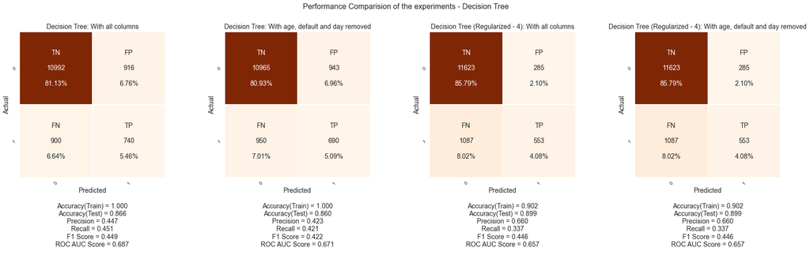

```python
num_plots = len(experiments.items())
total_cols = 4
total_rows = 1
fig_conf, axs = plt.subplots(nrows=total_rows, ncols=total_cols, figsize=(25,7))

exp_result = {}
all_results = {}
for i, (exp_k, exp_v) in enumerate(experiments.items()):
    row = i//total_cols
    pos = i % total_cols
    exp_data = decision_tree(axs, row, pos, exp_v["algo"] + ": " + exp_v["description"], exp_v["df"], exp_v["target"], exp_v["max_depth"])
    exp_result[i] = exp_data[6]
    all_results[i] = exp_data

# axs[2].set_axis_off()
fig_conf.tight_layout(pad=3.5)
fig_conf.suptitle("Performance Comparision of the experiments - Decision Tree", fontsize=16, y=1.05)
plt.show();
```

```python
temp_result_df = pd.DataFrame.from_dict(exp_result, orient="index", columns=["Description", "TN","FP","FN","TP", "Training Accuracy", "Testing Accuracy", "Precision", "Recall", "F1 Score", "ROC AUC Score"])
exp_result_df = pd.concat([exp_result_df, temp_result_df], ignore_index=True)
exp_result_df_disp = exp_result_df.copy()
exp_result_df_disp.style.apply(lambda x: ['background: yellow' if x.name in [2,3] else 'background: lightgreen' if x.name in [4] else '' for i in x], axis=1)
```

|  | Description | TN | FP | FN | TP | Training Accuracy | Testing Accuracy | Precision | Recall | F1 Score | ROC AUC Score |
| --- | --- | --- | --- | --- | --- | --- | --- | --- | --- | --- | --- |
| 0 | Logistic Regression: With all columns | 11697 | 211 | 1233 | 407 | 0.896 | 0.893 | 0.659 | 0.248 | 0.360 | 0.615 |
| 1 | Logistic Regression: With age, default and day removed | 11634 | 274 | 1119 | 521 | 0.899 | 0.897 | 0.655 | 0.318 | 0.428 | 0.647 |
| 2 | Decision Tree: With all columns | 10992 | 916 | 900 | 740 | 1.000 | 0.866 | 0.447 | 0.451 | 0.449 | 0.687 |
| 3 | Decision Tree: With age, default and day removed | 10965 | 943 | 950 | 690 | 1.000 | 0.860 | 0.423 | 0.421 | 0.422 | 0.671 |
| 4 | Decision Tree (Regularized - 4): With all columns | 11623 | 285 | 1087 | 553 | 0.902 | 0.899 | 0.660 | 0.337 | 0.446 | 0.657 |
| 5 | Decision Tree (Regularized - 4): With age, default and day removed | 11623 | 285 | 1087 | 553 | 0.902 | 0.899 | 0.660 | 0.337 | 0.446 | 0.657 |

##### Observation

Based on the values observed above, we see that Decision Tree has a better performance compared to Logistic Regression.  
Also within the Decision Tree (regularized), there isnt any difference with removing some of the columns, which helped with Logistic Regression.

With default decision tree, we see that the data is overfitted with training accuracy at **1.00** (rows in yellow).  
But with regularized (pruned) decision tree, we see that overfitting is reduced, but not considerable improvement in testing accuracy

Regularized Decision Tree gives us a **Recall = 0.337** and **Testing Accuracy = 0.899** which is pretty good.  
On closer observation, we see that the FN has come down. And TP has increased because of better conversion of FN to TP.  
This has increased the Recall score.

#### Visualizing the tree

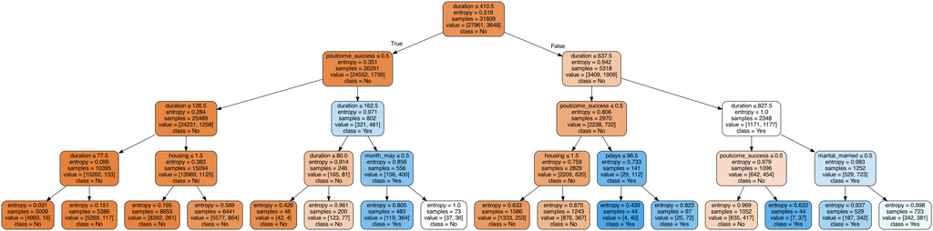

```python
X_train, X_test, y_train, y_test, dt_model, y_predict, return_list = all_results[3]

dot_data = StringIO()
export_graphviz(dt_model, out_file=dot_data, filled=True, rounded=True, special_characters=True, feature_names = list(X_train), class_names = ['No', 'Yes'])
graph = pydotplus.graph_from_dot_data(dot_data.getvalue())
graph.write_png('term_deposit_tree.png')
Image(graph.create_png())
```

#### Important features according to decision tree

```python
feat_importance = dt_model.tree_.compute_feature_importances(normalize=False)
feat_imp_dict = dict(zip(list(X_train), dt_model.feature_importances_))
feat_imp = pd.DataFrame.from_dict(feat_imp_dict, orient='index')
display(HTML(feat_imp[feat_imp[0] > 0].sort_values(by=0, ascending=False).to_html()))
```

|  | 0 |
| --- | --- |
| duration | 0.607823 |
| poutcome_success | 0.287615 |
| housing | 0.098144 |
| month_may | 0.002886 |
| marital_married | 0.002673 |
| pdays | 0.000859 |

##### Observation

Based on the seclected regularized decision tree, the important features are listed above.

### Ensemble

Now let us consider some of the ensemble techniques we know of.

```python
# Bagging

experiments = {}

# EXP1: First we will test with all columns
exp1_df = bank_mark_df[all_columns]
experiments["Experiment 1"] = {
    "df": exp1_df,
    "target": bank_mark_df[["Target"]],
    "algo": "Bagging (Logistic Regression)",
    "logit": True,
    "dt": False,
    "max_depth": None,
    "description": "With all columns"
}

# EXP2: With "age", "default", "day" removed
lesser_columns = all_columns.difference(["age", "default", "day"])
exp2_df = bank_mark_df[lesser_columns]
experiments["Experiment 2"] = {
    "df": exp2_df,
    "target": bank_mark_df[["Target"]],
    "algo": "Bagging (Logistic Regression)",
    "logit": True,
    "dt": False,
    "max_depth": None,
    "description": "With age, default and day removed"
}

# EXP3: all columns - regularized
exp3_df = bank_mark_df[all_columns]
experiments["Experiment 3"] = {
    "df": exp3_df,
    "target": bank_mark_df[["Target"]],
    "algo": "Bagging (Decision Tree - Regularized - 4)",
    "logit": False,
    "dt": True,
    "max_depth": 4,
    "description": "With all columns"
}

# EXP2: With "age", "default", "day" removed - regularized
lesser_columns = all_columns.difference(["age", "default", "day"])
exp4_df = bank_mark_df[lesser_columns]
experiments["Experiment 4"] = {
    "df": exp4_df,
    "target": bank_mark_df[["Target"]],
    "algo": "Bagging (Decision Tree - Regularized - 4)",
    "logit": False,
    "dt": True,
    "max_depth": 4,
    "description": "With age, default and day removed"
}
```

```
******************************** Bagging (Logistic Regression): With all columns ******************************************************

Splitting data for                         : Bagging (Logistic Regression): With all columns
Original Term Deposit Subscribed Values     : 5288 (11.71%)
Original Term Deposit Not Subscribed Values : 39869 (88.29%)

Training Term Deposit Subscribed Values     : 3648 (11.54%)
Training Term Deposit Not Subscribed Values : 27961 (88.46%)

Test Term Deposit Subscribed Values         : 1640 (12.11%)
Test Term Deposit Not Subscribed Values     : 11908 (87.89%)

******************************** Bagging (Logistic Regression): With age, default and day removed ******************************************************

Splitting data for                         : Bagging (Logistic Regression): With age, default and day removed
Original Term Deposit Subscribed Values     : 5288 (11.71%)
Original Term Deposit Not Subscribed Values : 39869 (88.29%)

Training Term Deposit Subscribed Values     : 3648 (11.54%)
Training Term Deposit Not Subscribed Values : 27961 (88.46%)

Test Term Deposit Subscribed Values         : 1640 (12.11%)
Test Term Deposit Not Subscribed Values     : 11908 (87.89%)

******************************** Bagging (Decision Tree - Regularized - 4): With all columns ******************************************************

Splitting data for                         : Bagging (Decision Tree - Regularized - 4): With all columns
Original Term Deposit Subscribed Values     : 5288 (11.71%)
Original Term Deposit Not Subscribed Values : 39869 (88.29%)

Training Term Deposit Subscribed Values     : 3648 (11.54%)
Training Term Deposit Not Subscribed Values : 27961 (88.46%)

Test Term Deposit Subscribed Values         : 1640 (12.11%)
Test Term Deposit Not Subscribed Values     : 11908 (87.89%)

******************************** Bagging (Decision Tree - Regularized - 4): With age, default and day removed ******************************************************

Splitting data for                         : Bagging (Decision Tree - Regularized - 4): With age, default and day removed
Original Term Deposit Subscribed Values     : 5288 (11.71%)
Original Term Deposit Not Subscribed Values : 39869 (88.29%)

Training Term Deposit Subscribed Values     : 3648 (11.54%)
Training Term Deposit Not Subscribed Values : 27961 (88.46%)

Test Term Deposit Subscribed Values         : 1640 (12.11%)
Test Term Deposit Not Subscribed Values     : 11908 (87.89%)
```

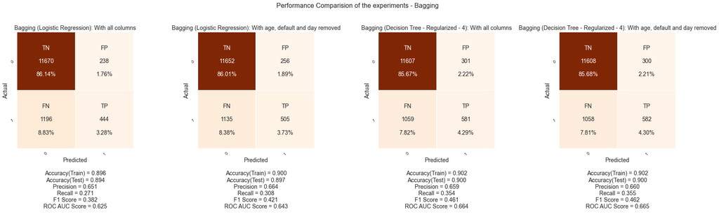

```python
num_plots = len(experiments.items())
total_cols = 4
total_rows = 1
fig_conf, axs = plt.subplots(nrows=total_rows, ncols=total_cols, figsize=(25,7))

exp_result = {}
all_results = {}
for i, (exp_k, exp_v) in enumerate(experiments.items()):
    row = i//total_cols
    pos = i % total_cols
    exp_data = bagging(axs, row, pos, exp_v["algo"] + ": " + exp_v["description"], exp_v["df"], exp_v["target"], exp_v["max_depth"], exp_v["logit"], exp_v["dt"])
    exp_result[i] = exp_data[6]
    all_results[i] = exp_data

# axs[2].set_axis_off()
fig_conf.tight_layout(pad=3.5)
fig_conf.suptitle("Performance Comparision of the experiments - Bagging", fontsize=16, y=1.05)
plt.show();
```

```python
temp_result_df = pd.DataFrame.from_dict(exp_result, orient="index", columns=["Description", "TN","FP","FN","TP", "Training Accuracy", "Testing Accuracy", "Precision", "Recall", "F1 Score", "ROC AUC Score"])
exp_result_df = pd.concat([exp_result_df, temp_result_df], ignore_index=True)
exp_result_df_disp = exp_result_df.copy()
exp_result_df_disp.style.apply(lambda x: ['background: yellow' if x.name in [6,7] else 'background: lightgreen' if x.name in [8] else '' for i in x], axis=1)
```

|  | Description | TN | FP | FN | TP | Training Accuracy | Testing Accuracy | Precision | Recall | F1 Score | ROC AUC Score |
| --- | --- | --- | --- | --- | --- | --- | --- | --- | --- | --- | --- |
| 0 | Logistic Regression: With all columns | 11697 | 211 | 1233 | 407 | 0.896 | 0.893 | 0.659 | 0.248 | 0.360 | 0.615 |
| 1 | Logistic Regression: With age, default and day removed | 11634 | 274 | 1119 | 521 | 0.899 | 0.897 | 0.655 | 0.318 | 0.428 | 0.647 |
| 2 | Decision Tree: With all columns | 10992 | 916 | 900 | 740 | 1.000 | 0.866 | 0.447 | 0.451 | 0.449 | 0.687 |
| 3 | Decision Tree: With age, default and day removed | 10965 | 943 | 950 | 690 | 1.000 | 0.860 | 0.423 | 0.421 | 0.422 | 0.671 |
| 4 | Decision Tree (Regularized - 4): With all columns | 11623 | 285 | 1087 | 553 | 0.902 | 0.899 | 0.660 | 0.337 | 0.446 | 0.657 |
| 5 | Decision Tree (Regularized - 4): With age, default and day removed | 11623 | 285 | 1087 | 553 | 0.902 | 0.899 | 0.660 | 0.337 | 0.446 | 0.657 |
| 6 | Bagging (Logistic Regression): With all columns | 11670 | 238 | 1196 | 444 | 0.896 | 0.894 | 0.651 | 0.271 | 0.382 | 0.625 |
| 7 | Bagging (Logistic Regression): With age, default and day removed | 11652 | 256 | 1135 | 505 | 0.900 | 0.897 | 0.664 | 0.308 | 0.421 | 0.643 |
| 8 | Bagging (Decision Tree - Regularized - 4): With all columns | 11607 | 301 | 1059 | 581 | 0.902 | 0.900 | 0.659 | 0.354 | 0.461 | 0.664 |
| 9 | Bagging (Decision Tree - Regularized - 4): With age, default and day removed | 11608 | 300 | 1058 | 582 | 0.902 | 0.900 | 0.660 | 0.355 | 0.462 | 0.665 |

##### Observation

- Bagging with Logistic Regression (yellow rows):
  - Perform slightly better than regular Logistic Regression.
  - FN did go down slightly and TP has also increased a bit. Recall moved to **0.271**
- Bagging with Regularized Decision Tree:
  - Performs slightly better than regular decision trees, for both the cases.
  - Accuracy incrased.
  - Recall went up slightly to **0.354**
  - TP went up slightly and FN went down as well, given a higher Recall as compared to regular Decision Trees
- Overall bagging does seem to provide a better performance so far.

```
******************************** Random Forest (Regularized - 4): With all columns ******************************************************

Splitting data for                         : Random Forest (Regularized - 4): With all columns
Original Term Deposit Subscribed Values     : 5288 (11.71%)
Original Term Deposit Not Subscribed Values : 39869 (88.29%)

Training Term Deposit Subscribed Values     : 3648 (11.54%)
Training Term Deposit Not Subscribed Values : 27961 (88.46%)

Test Term Deposit Subscribed Values         : 1640 (12.11%)
Test Term Deposit Not Subscribed Values     : 11908 (87.89%)

******************************** Random Forest (Regularized - 4): With age, default and day removed ******************************************************

Splitting data for                         : Random Forest (Regularized - 4): With age, default and day removed
Original Term Deposit Subscribed Values     : 5288 (11.71%)
Original Term Deposit Not Subscribed Values : 39869 (88.29%)

Training Term Deposit Subscribed Values     : 3648 (11.54%)
Training Term Deposit Not Subscribed Values : 27961 (88.46%)

Test Term Deposit Subscribed Values         : 1640 (12.11%)
Test Term Deposit Not Subscribed Values     : 11908 (87.89%)
```

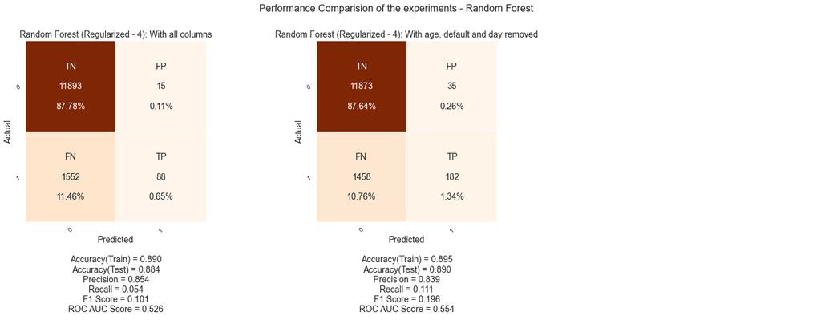

```python
# Random Forest

experiments = {}

# EXP1: First we will test with all columns
exp1_df = bank_mark_df[all_columns]
experiments["Experiment 1"] = {
    "df": exp1_df,
    "target": bank_mark_df[["Target"]],
    "algo": "Random Forest (Regularized - 4)",
    "max_depth": 4,
    "description": "With all columns"
}

# EXP2: With "age", "default", "day" removed
lesser_columns = all_columns.difference(["age", "default", "day"])
exp2_df = bank_mark_df[lesser_columns]
experiments["Experiment 2"] = {
    "df": exp2_df,
    "target": bank_mark_df[["Target"]],
    "algo": "Random Forest (Regularized - 4)",
    "max_depth": 4,
    "description": "With age, default and day removed"
}

num_plots = len(experiments.items())
total_cols = 3
total_rows = 1
fig_conf, axs = plt.subplots(nrows=total_rows, ncols=total_cols, figsize=(20,7))

exp_result = {}
all_results = {}
for i, (exp_k, exp_v) in enumerate(experiments.items()):
    row = i//total_cols
    pos = i % total_cols
    exp_data = random_forest(axs, row, pos, exp_v["algo"] + ": " + exp_v["description"], exp_v["df"], exp_v["target"], exp_v["max_depth"])
    exp_result[i] = exp_data[6]
    all_results[i] = exp_data

axs[2].set_axis_off()
fig_conf.tight_layout(pad=3.5)
fig_conf.suptitle("Performance Comparision of the experiments - Random Forest", fontsize=16, y=1.05)
plt.show();
```

```python
temp_result_df = pd.DataFrame.from_dict(exp_result, orient="index", columns=["Description", "TN","FP","FN","TP", "Training Accuracy", "Testing Accuracy", "Precision", "Recall", "F1 Score", "ROC AUC Score"])
exp_result_df = pd.concat([exp_result_df, temp_result_df], ignore_index=True)
exp_result_df_disp = exp_result_df.copy()
exp_result_df_disp.style.apply(lambda x: ['background: lightgreen' if x.name in [10,11] else '' for i in x], axis=1)
```

|  | Description | TN | FP | FN | TP | Training Accuracy | Testing Accuracy | Precision | Recall | F1 Score | ROC AUC Score |
| --- | --- | --- | --- | --- | --- | --- | --- | --- | --- | --- | --- |
| 0 | Logistic Regression: With all columns | 11697 | 211 | 1233 | 407 | 0.896 | 0.893 | 0.659 | 0.248 | 0.360 | 0.615 |
| 1 | Logistic Regression: With age, default and day removed | 11634 | 274 | 1119 | 521 | 0.899 | 0.897 | 0.655 | 0.318 | 0.428 | 0.647 |
| 2 | Decision Tree: With all columns | 10992 | 916 | 900 | 740 | 1.000 | 0.866 | 0.447 | 0.451 | 0.449 | 0.687 |
| 3 | Decision Tree: With age, default and day removed | 10965 | 943 | 950 | 690 | 1.000 | 0.860 | 0.423 | 0.421 | 0.422 | 0.671 |
| 4 | Decision Tree (Regularized - 4): With all columns | 11623 | 285 | 1087 | 553 | 0.902 | 0.899 | 0.660 | 0.337 | 0.446 | 0.657 |
| 5 | Decision Tree (Regularized - 4): With age, default and day removed | 11623 | 285 | 1087 | 553 | 0.902 | 0.899 | 0.660 | 0.337 | 0.446 | 0.657 |
| 6 | Bagging (Logistic Regression): With all columns | 11670 | 238 | 1196 | 444 | 0.896 | 0.894 | 0.651 | 0.271 | 0.382 | 0.625 |
| 7 | Bagging (Logistic Regression): With age, default and day removed | 11652 | 256 | 1135 | 505 | 0.900 | 0.897 | 0.664 | 0.308 | 0.421 | 0.643 |
| 8 | Bagging (Decision Tree - Regularized - 4): With all columns | 11607 | 301 | 1059 | 581 | 0.902 | 0.900 | 0.659 | 0.354 | 0.461 | 0.664 |
| 9 | Bagging (Decision Tree - Regularized - 4): With age, default and day removed | 11608 | 300 | 1058 | 582 | 0.902 | 0.900 | 0.660 | 0.355 | 0.462 | 0.665 |
| 10 | Random Forest (Regularized - 4): With all columns | 11893 | 15 | 1552 | 88 | 0.890 | 0.884 | 0.854 | 0.054 | 0.101 | 0.526 |
| 11 | Random Forest (Regularized - 4): With age, default and day removed | 11873 | 35 | 1458 | 182 | 0.895 | 0.890 | 0.839 | 0.111 | 0.196 | 0.554 |

##### Observation

- Random Forest (Regularized - 4):
  - It has a good accuracy
  - Recall has deteriorated to **0.054** and **0.111**
  - But we see that the TP has gone down considerably with Random Forest and FN has increased as well
- Looks like Random forest is not a good choice for this problem

```python
# AdaBoost

experiments = {}

# EXP1: First we will test with all columns
exp1_df = bank_mark_df[all_columns]
experiments["Experiment 1"] = {
    "df": exp1_df,
    "target": bank_mark_df[["Target"]],
    "algo": "AdaBoost (Logistic Regression)",
    "logit": True,
    "dt": False,
    "max_depth": None,
    "description": "With all columns"
}

# EXP2: With "age", "default", "day" removed
lesser_columns = all_columns.difference(["age", "default", "day"])
exp2_df = bank_mark_df[lesser_columns]
experiments["Experiment 2"] = {
    "df": exp2_df,
    "target": bank_mark_df[["Target"]],
    "algo": "AdaBoost (Logistic Regression)",
    "logit": True,
    "dt": False,
    "max_depth": None,
    "description": "With age, default and day removed"
}

# EXP3: all columns - regularized
exp3_df = bank_mark_df[all_columns]
experiments["Experiment 3"] = {
    "df": exp3_df,
    "target": bank_mark_df[["Target"]],
    "algo": "AdaBoost (Decision Tree - 1)",
    "logit": False,
    "dt": True,
    "max_depth": 1,
    "description": "With all columns"
}

# EXP2: With "age", "default", "day" removed - regularized
lesser_columns = all_columns.difference(["age", "default", "day"])
exp4_df = bank_mark_df[lesser_columns]
experiments["Experiment 4"] = {
    "df": exp4_df,
    "target": bank_mark_df[["Target"]],
    "algo": "AdaBoost (Decision Tree - 1)",
    "logit": False,
    "dt": True,
    "max_depth": 1,
    "description": "With age, default and day removed"
}
```

```
******************************** AdaBoost (Logistic Regression): With all columns ******************************************************

Splitting data for                         : AdaBoost (Logistic Regression): With all columns
Original Term Deposit Subscribed Values     : 5288 (11.71%)
Original Term Deposit Not Subscribed Values : 39869 (88.29%)

Training Term Deposit Subscribed Values     : 3648 (11.54%)
Training Term Deposit Not Subscribed Values : 27961 (88.46%)

Test Term Deposit Subscribed Values         : 1640 (12.11%)
Test Term Deposit Not Subscribed Values     : 11908 (87.89%)

******************************** AdaBoost (Logistic Regression): With age, default and day removed ******************************************************

Splitting data for                         : AdaBoost (Logistic Regression): With age, default and day removed
Original Term Deposit Subscribed Values     : 5288 (11.71%)
Original Term Deposit Not Subscribed Values : 39869 (88.29%)

Training Term Deposit Subscribed Values     : 3648 (11.54%)
Training Term Deposit Not Subscribed Values : 27961 (88.46%)

Test Term Deposit Subscribed Values         : 1640 (12.11%)
Test Term Deposit Not Subscribed Values     : 11908 (87.89%)

******************************** AdaBoost (Decision Tree - 1): With all columns ******************************************************

Splitting data for                         : AdaBoost (Decision Tree - 1): With all columns
Original Term Deposit Subscribed Values     : 5288 (11.71%)
Original Term Deposit Not Subscribed Values : 39869 (88.29%)

Training Term Deposit Subscribed Values     : 3648 (11.54%)
Training Term Deposit Not Subscribed Values : 27961 (88.46%)

Test Term Deposit Subscribed Values         : 1640 (12.11%)
Test Term Deposit Not Subscribed Values     : 11908 (87.89%)

******************************** AdaBoost (Decision Tree - 1): With age, default and day removed ******************************************************

Splitting data for                         : AdaBoost (Decision Tree - 1): With age, default and day removed
Original Term Deposit Subscribed Values     : 5288 (11.71%)
Original Term Deposit Not Subscribed Values : 39869 (88.29%)

Training Term Deposit Subscribed Values     : 3648 (11.54%)
Training Term Deposit Not Subscribed Values : 27961 (88.46%)

Test Term Deposit Subscribed Values         : 1640 (12.11%)
Test Term Deposit Not Subscribed Values     : 11908 (87.89%)
```

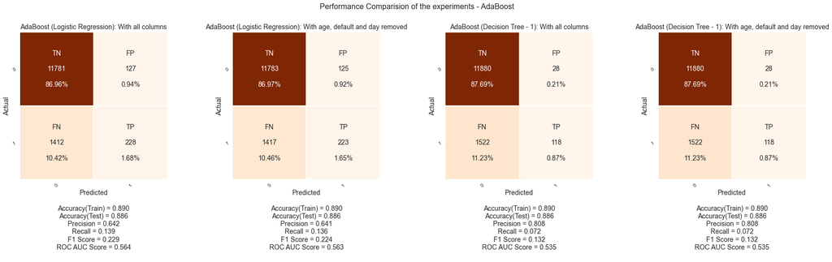

```python
num_plots = len(experiments.items())
total_cols = 4
total_rows = 1
fig_conf, axs = plt.subplots(nrows=total_rows, ncols=total_cols, figsize=(25,7))

exp_result = {}
all_results = {}
for i, (exp_k, exp_v) in enumerate(experiments.items()):
    row = i//total_cols
    pos = i % total_cols
    exp_data = ada_boost(axs, row, pos, exp_v["algo"] + ": " + exp_v["description"], exp_v["df"], exp_v["target"], exp_v["max_depth"], exp_v["logit"], exp_v["dt"])
    exp_result[i] = exp_data[6]
    all_results[i] = exp_data

# axs[2].set_axis_off()
fig_conf.tight_layout(pad=3.5)
fig_conf.suptitle("Performance Comparision of the experiments - AdaBoost", fontsize=16, y=1.05)
plt.show();
```

```python
temp_result_df = pd.DataFrame.from_dict(exp_result, orient="index", columns=["Description", "TN","FP","FN","TP", "Training Accuracy", "Testing Accuracy", "Precision", "Recall", "F1 Score", "ROC AUC Score"])
exp_result_df = pd.concat([exp_result_df, temp_result_df], ignore_index=True)
exp_result_df_disp = exp_result_df.copy()
exp_result_df_disp.style.apply(lambda x: ['background: yellow' if x.name in [12,13] else 'background: lightgreen' if x.name in [14,15] else '' for i in x], axis=1)
```

|  | Description | TN | FP | FN | TP | Training Accuracy | Testing Accuracy | Precision | Recall | F1 Score | ROC AUC Score |
| --- | --- | --- | --- | --- | --- | --- | --- | --- | --- | --- | --- |
| 0 | Logistic Regression: With all columns | 11697 | 211 | 1233 | 407 | 0.896 | 0.893 | 0.659 | 0.248 | 0.360 | 0.615 |
| 1 | Logistic Regression: With age, default and day removed | 11634 | 274 | 1119 | 521 | 0.899 | 0.897 | 0.655 | 0.318 | 0.428 | 0.647 |
| 2 | Decision Tree: With all columns | 10992 | 916 | 900 | 740 | 1.000 | 0.866 | 0.447 | 0.451 | 0.449 | 0.687 |
| 3 | Decision Tree: With age, default and day removed | 10965 | 943 | 950 | 690 | 1.000 | 0.860 | 0.423 | 0.421 | 0.422 | 0.671 |
| 4 | Decision Tree (Regularized - 4): With all columns | 11623 | 285 | 1087 | 553 | 0.902 | 0.899 | 0.660 | 0.337 | 0.446 | 0.657 |
| 5 | Decision Tree (Regularized - 4): With age, default and day removed | 11623 | 285 | 1087 | 553 | 0.902 | 0.899 | 0.660 | 0.337 | 0.446 | 0.657 |
| 6 | Bagging (Logistic Regression): With all columns | 11670 | 238 | 1196 | 444 | 0.896 | 0.894 | 0.651 | 0.271 | 0.382 | 0.625 |
| 7 | Bagging (Logistic Regression): With age, default and day removed | 11652 | 256 | 1135 | 505 | 0.900 | 0.897 | 0.664 | 0.308 | 0.421 | 0.643 |
| 8 | Bagging (Decision Tree - Regularized - 4): With all columns | 11607 | 301 | 1059 | 581 | 0.902 | 0.900 | 0.659 | 0.354 | 0.461 | 0.664 |
| 9 | Bagging (Decision Tree - Regularized - 4): With age, default and day removed | 11608 | 300 | 1058 | 582 | 0.902 | 0.900 | 0.660 | 0.355 | 0.462 | 0.665 |
| 10 | Random Forest (Regularized - 4): With all columns | 11893 | 15 | 1552 | 88 | 0.890 | 0.884 | 0.854 | 0.054 | 0.101 | 0.526 |
| 11 | Random Forest (Regularized - 4): With age, default and day removed | 11873 | 35 | 1458 | 182 | 0.895 | 0.890 | 0.839 | 0.111 | 0.196 | 0.554 |
| 12 | AdaBoost (Logistic Regression): With all columns | 11781 | 127 | 1412 | 228 | 0.890 | 0.886 | 0.642 | 0.139 | 0.229 | 0.564 |
| 13 | AdaBoost (Logistic Regression): With age, default and day removed | 11783 | 125 | 1417 | 223 | 0.890 | 0.886 | 0.641 | 0.136 | 0.224 | 0.563 |
| 14 | AdaBoost (Decision Tree - 1): With all columns | 11880 | 28 | 1522 | 118 | 0.890 | 0.886 | 0.808 | 0.072 | 0.132 | 0.535 |
| 15 | AdaBoost (Decision Tree - 1): With age, default and day removed | 11880 | 28 | 1522 | 118 | 0.890 | 0.886 | 0.808 | 0.072 | 0.132 | 0.535 |

##### Observation

- AdaBoost with Logistic Regression (yellow rows):
  - Doesnt perform any better than regular Logistic Regression, for both "all columns" and some columns removed.
  - The FN went up with AdaBoost. Also TP went down as well
- AdaBoost with Decision Tree (green rows):
  - Performs worse than regular decision trees
  - Accuracy gone down
  - Recall also went down to **0.072**
- Doesnt look like AdaBoost is a good choice for this problem

```
******************************** GradientBoost (Regularized - 4): With all columns ******************************************************

Splitting data for                         : GradientBoost (Regularized - 4): With all columns
Original Term Deposit Subscribed Values     : 5288 (11.71%)
Original Term Deposit Not Subscribed Values : 39869 (88.29%)

Training Term Deposit Subscribed Values     : 3648 (11.54%)
Training Term Deposit Not Subscribed Values : 27961 (88.46%)

Test Term Deposit Subscribed Values         : 1640 (12.11%)
Test Term Deposit Not Subscribed Values     : 11908 (87.89%)

******************************** GradientBoost (Regularized - 4): With age, default and day removed ******************************************************

Splitting data for                         : GradientBoost (Regularized - 4): With age, default and day removed
Original Term Deposit Subscribed Values     : 5288 (11.71%)
Original Term Deposit Not Subscribed Values : 39869 (88.29%)

Training Term Deposit Subscribed Values     : 3648 (11.54%)
Training Term Deposit Not Subscribed Values : 27961 (88.46%)

Test Term Deposit Subscribed Values         : 1640 (12.11%)
Test Term Deposit Not Subscribed Values     : 11908 (87.89%)
```

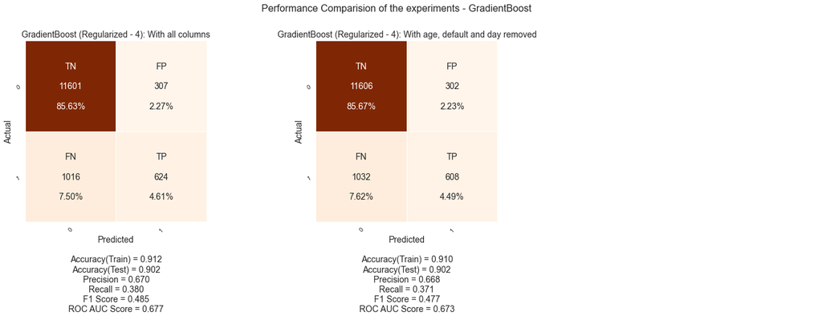

```python
# GradientBoost

experiments = {}

# EXP1: First we will test with all columns
exp1_df = bank_mark_df[all_columns]
experiments["Experiment 1"] = {
    "df": exp1_df,
    "target": bank_mark_df[["Target"]],
    "algo": "GradientBoost (Regularized - 4)",
    "max_depth": 4,
    "description": "With all columns"
}

# EXP2: With "age", "default", "day" removed
lesser_columns = all_columns.difference(["age", "default", "day"])
exp2_df = bank_mark_df[lesser_columns]
experiments["Experiment 2"] = {
    "df": exp2_df,
    "target": bank_mark_df[["Target"]],
    "algo": "GradientBoost (Regularized - 4)",
    "max_depth": 4,
    "description": "With age, default and day removed"
}

num_plots = len(experiments.items())
total_cols = 3
total_rows = 1
fig_conf, axs = plt.subplots(nrows=total_rows, ncols=total_cols, figsize=(20,7))

exp_result = {}
all_results = {}
for i, (exp_k, exp_v) in enumerate(experiments.items()):
    row = i//total_cols
    pos = i % total_cols
    exp_data = grad_boost(axs, row, pos, exp_v["algo"] + ": " + exp_v["description"], exp_v["df"], exp_v["target"], exp_v["max_depth"])
    exp_result[i] = exp_data[6]
    all_results[i] = exp_data

axs[2].set_axis_off()
fig_conf.tight_layout(pad=3.5)
fig_conf.suptitle("Performance Comparision of the experiments - GradientBoost", fontsize=16, y=1.05)
plt.show();
```

```python
temp_result_df = pd.DataFrame.from_dict(exp_result, orient="index", columns=["Description", "TN","FP","FN","TP", "Training Accuracy", "Testing Accuracy", "Precision", "Recall", "F1 Score", "ROC AUC Score"])
exp_result_df = pd.concat([exp_result_df, temp_result_df], ignore_index=True)
exp_result_df_disp = exp_result_df.copy()
exp_result_df_disp.style.apply(lambda x: ['background: lightgreen' if x.name in [16,17] else '' for i in x], axis=1)
```

|  | Description | TN | FP | FN | TP | Training Accuracy | Testing Accuracy | Precision | Recall | F1 Score | ROC AUC Score |
| --- | --- | --- | --- | --- | --- | --- | --- | --- | --- | --- | --- |
| 0 | Logistic Regression: With all columns | 11697 | 211 | 1233 | 407 | 0.896 | 0.893 | 0.659 | 0.248 | 0.360 | 0.615 |
| 1 | Logistic Regression: With age, default and day removed | 11634 | 274 | 1119 | 521 | 0.899 | 0.897 | 0.655 | 0.318 | 0.428 | 0.647 |
| 2 | Decision Tree: With all columns | 10992 | 916 | 900 | 740 | 1.000 | 0.866 | 0.447 | 0.451 | 0.449 | 0.687 |
| 3 | Decision Tree: With age, default and day removed | 10965 | 943 | 950 | 690 | 1.000 | 0.860 | 0.423 | 0.421 | 0.422 | 0.671 |
| 4 | Decision Tree (Regularized - 4): With all columns | 11623 | 285 | 1087 | 553 | 0.902 | 0.899 | 0.660 | 0.337 | 0.446 | 0.657 |
| 5 | Decision Tree (Regularized - 4): With age, default and day removed | 11623 | 285 | 1087 | 553 | 0.902 | 0.899 | 0.660 | 0.337 | 0.446 | 0.657 |
| 6 | Bagging (Logistic Regression): With all columns | 11670 | 238 | 1196 | 444 | 0.896 | 0.894 | 0.651 | 0.271 | 0.382 | 0.625 |
| 7 | Bagging (Logistic Regression): With age, default and day removed | 11652 | 256 | 1135 | 505 | 0.900 | 0.897 | 0.664 | 0.308 | 0.421 | 0.643 |
| 8 | Bagging (Decision Tree - Regularized - 4): With all columns | 11607 | 301 | 1059 | 581 | 0.902 | 0.900 | 0.659 | 0.354 | 0.461 | 0.664 |
| 9 | Bagging (Decision Tree - Regularized - 4): With age, default and day removed | 11608 | 300 | 1058 | 582 | 0.902 | 0.900 | 0.660 | 0.355 | 0.462 | 0.665 |
| 10 | Random Forest (Regularized - 4): With all columns | 11893 | 15 | 1552 | 88 | 0.890 | 0.884 | 0.854 | 0.054 | 0.101 | 0.526 |
| 11 | Random Forest (Regularized - 4): With age, default and day removed | 11873 | 35 | 1458 | 182 | 0.895 | 0.890 | 0.839 | 0.111 | 0.196 | 0.554 |
| 12 | AdaBoost (Logistic Regression): With all columns | 11781 | 127 | 1412 | 228 | 0.890 | 0.886 | 0.642 | 0.139 | 0.229 | 0.564 |
| 13 | AdaBoost (Logistic Regression): With age, default and day removed | 11783 | 125 | 1417 | 223 | 0.890 | 0.886 | 0.641 | 0.136 | 0.224 | 0.563 |
| 14 | AdaBoost (Decision Tree - 1): With all columns | 11880 | 28 | 1522 | 118 | 0.890 | 0.886 | 0.808 | 0.072 | 0.132 | 0.535 |
| 15 | AdaBoost (Decision Tree - 1): With age, default and day removed | 11880 | 28 | 1522 | 118 | 0.890 | 0.886 | 0.808 | 0.072 | 0.132 | 0.535 |
| 16 | GradientBoost (Regularized - 4): With all columns | 11601 | 307 | 1016 | 624 | 0.912 | 0.902 | 0.670 | 0.380 | 0.485 | 0.677 |
| 17 | GradientBoost (Regularized - 4): With age, default and day removed | 11606 | 302 | 1032 | 608 | 0.910 | 0.902 | 0.668 | 0.371 | 0.477 | 0.673 |

##### Observation

- GradientBoost (Regularized - 4):
  - It has a good accuracy
  - Recall is good at **0.380** for all columns and **0.371** for case with some columns removed.
  - The TP has increased significantly and FN has gone down as well
  - So decrease in FN accounts for higher recall.
- So far this seems to be the best model for this problem

Lets look at some more visualization for **GradientBoost (Regularized - 4): With all columns**

```python
X_train, X_test, y_train, y_test, gb_model, y_predict, return_list = all_results[0]
```

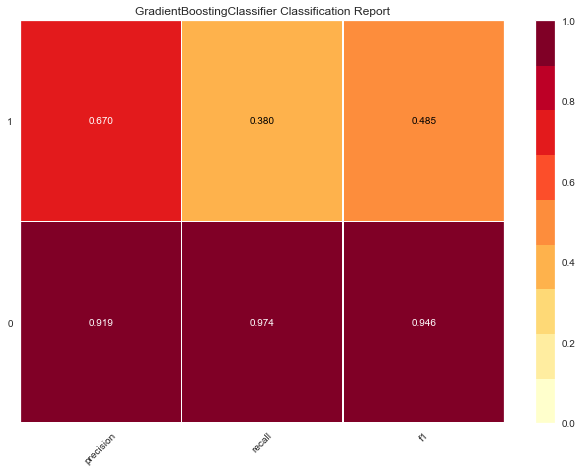

```python
viz = ClassificationReport(gb_model, size=(640, 480))
viz.fit(X_train, y_train)
viz.score(X_test, y_test)
viz.show();
```

##### Observation

- Precision and Recall for prediction a customer will not subscribe a Term Deposit is pretty good.

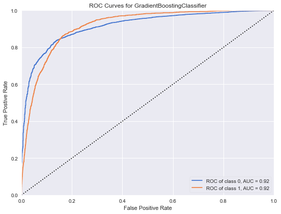

```python
roc = ROCAUC(gb_model, size=(640, 480), micro=False, macro=False, per_class=True)
roc.fit(X_train, y_train)
roc.score(X_test, y_test)
roc.show();
```

### Conclusion

So after the above experiments, we have the follow values collected

```python
exp_result_df_disp = exp_result_df.copy()
exp_result_df_disp.style.apply(lambda x: ['background: orange' if x.name in [2,3] else 'background: lightgreen' if x.name in [16] else '' for i in x], axis=1)
```

|  | Description | TN | FP | FN | TP | Training Accuracy | Testing Accuracy | Precision | Recall | F1 Score | ROC AUC Score |
| --- | --- | --- | --- | --- | --- | --- | --- | --- | --- | --- | --- |
| 0 | Logistic Regression: With all columns | 11697 | 211 | 1233 | 407 | 0.896 | 0.893 | 0.659 | 0.248 | 0.360 | 0.615 |
| 1 | Logistic Regression: With age, default and day removed | 11634 | 274 | 1119 | 521 | 0.899 | 0.897 | 0.655 | 0.318 | 0.428 | 0.647 |
| 2 | Decision Tree: With all columns | 10992 | 916 | 900 | 740 | 1.000 | 0.866 | 0.447 | 0.451 | 0.449 | 0.687 |
| 3 | Decision Tree: With age, default and day removed | 10965 | 943 | 950 | 690 | 1.000 | 0.860 | 0.423 | 0.421 | 0.422 | 0.671 |
| 4 | Decision Tree (Regularized - 4): With all columns | 11623 | 285 | 1087 | 553 | 0.902 | 0.899 | 0.660 | 0.337 | 0.446 | 0.657 |
| 5 | Decision Tree (Regularized - 4): With age, default and day removed | 11623 | 285 | 1087 | 553 | 0.902 | 0.899 | 0.660 | 0.337 | 0.446 | 0.657 |
| 6 | Bagging (Logistic Regression): With all columns | 11670 | 238 | 1196 | 444 | 0.896 | 0.894 | 0.651 | 0.271 | 0.382 | 0.625 |
| 7 | Bagging (Logistic Regression): With age, default and day removed | 11652 | 256 | 1135 | 505 | 0.900 | 0.897 | 0.664 | 0.308 | 0.421 | 0.643 |
| 8 | Bagging (Decision Tree - Regularized - 4): With all columns | 11607 | 301 | 1059 | 581 | 0.902 | 0.900 | 0.659 | 0.354 | 0.461 | 0.664 |
| 9 | Bagging (Decision Tree - Regularized - 4): With age, default and day removed | 11608 | 300 | 1058 | 582 | 0.902 | 0.900 | 0.660 | 0.355 | 0.462 | 0.665 |
| 10 | Random Forest (Regularized - 4): With all columns | 11893 | 15 | 1552 | 88 | 0.890 | 0.884 | 0.854 | 0.054 | 0.101 | 0.526 |
| 11 | Random Forest (Regularized - 4): With age, default and day removed | 11873 | 35 | 1458 | 182 | 0.895 | 0.890 | 0.839 | 0.111 | 0.196 | 0.554 |
| 12 | AdaBoost (Logistic Regression): With all columns | 11781 | 127 | 1412 | 228 | 0.890 | 0.886 | 0.642 | 0.139 | 0.229 | 0.564 |
| 13 | AdaBoost (Logistic Regression): With age, default and day removed | 11783 | 125 | 1417 | 223 | 0.890 | 0.886 | 0.641 | 0.136 | 0.224 | 0.563 |
| 14 | AdaBoost (Decision Tree - 1): With all columns | 11880 | 28 | 1522 | 118 | 0.890 | 0.886 | 0.808 | 0.072 | 0.132 | 0.535 |
| 15 | AdaBoost (Decision Tree - 1): With age, default and day removed | 11880 | 28 | 1522 | 118 | 0.890 | 0.886 | 0.808 | 0.072 | 0.132 | 0.535 |
| 16 | GradientBoost (Regularized - 4): With all columns | 11601 | 307 | 1016 | 624 | 0.912 | 0.902 | 0.670 | 0.380 | 0.485 | 0.677 |
| 17 | GradientBoost (Regularized - 4): With age, default and day removed | 11606 | 302 | 1032 | 608 | 0.910 | 0.902 | 0.668 | 0.371 | 0.477 | 0.673 |

- Lets **ignore** the results for *overfitted* Decision Trees (orange rows)  
  From the above results (green row), we can see that **GradientBoost (Regularized - 4): With all columns** is the model that outperforms all other models because of
- Highest Testing Accuracy **0.902**
- Good Precision **0.670**
- Highest Recall **0.380** (ignoring overfitted decision tree)
- Highest F1 Score **0.485**
- Highest ROC AUC Score **0.677** (ignoring overfitted decision tree)

After achieving the desired Recall we can deploy the model for practical use. As in the bank now can predict who is subscribe for a Term Deposit. They can use the model for upcoming campaign.